# Pekan 2 — Data Visualization

# 12. Bivariate: Categorical × Categorical

Pertanyaan:

> Apakah komposisi status klaim berbeda berdasarkan jenis kelamin?

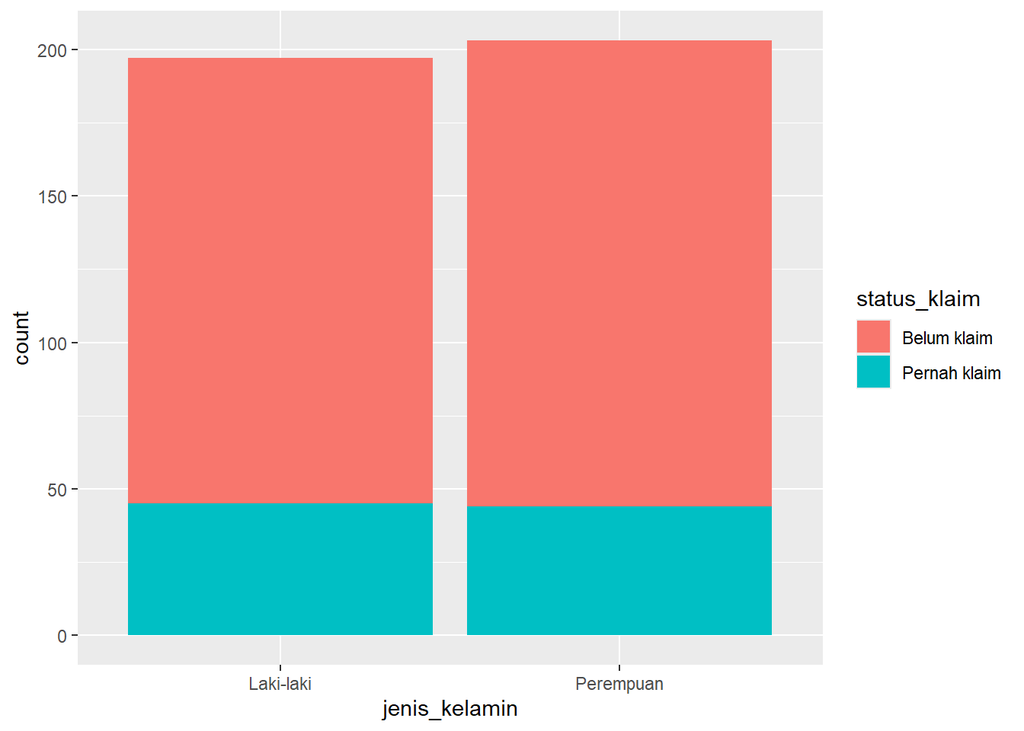

```r
ggplot(
  data_raw,
  aes(x = jenis_kelamin, fill = status_klaim)
) +
  geom_bar()
```

Grafik ini membandingkan jumlah.

Untuk membandingkan **proporsi**, gunakan:

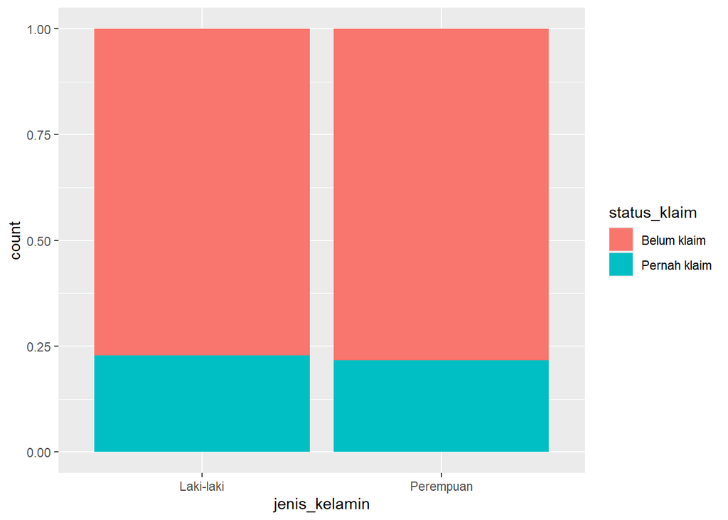

```r
ggplot(
  data_raw,
  aes(x = jenis_kelamin, fill = status_klaim)
) +
  geom_bar(position = "fill")
```

`position = "fill"` membuat setiap kelompok memiliki tinggi 100%.

Ini berguna ketika jumlah anggota setiap kelompok berbeda.

### Perbedaan penting

`position = "stack"`

→ membandingkan **jumlah**.

`position = "fill"`

→ membandingkan **proporsi**.

## 12.1 Grouped, Stacked, dan 100% Stacked: Memilih yang Tepat

Ketiganya memakai data yang sama, tetapi menjawab pertanyaan yang berbeda.

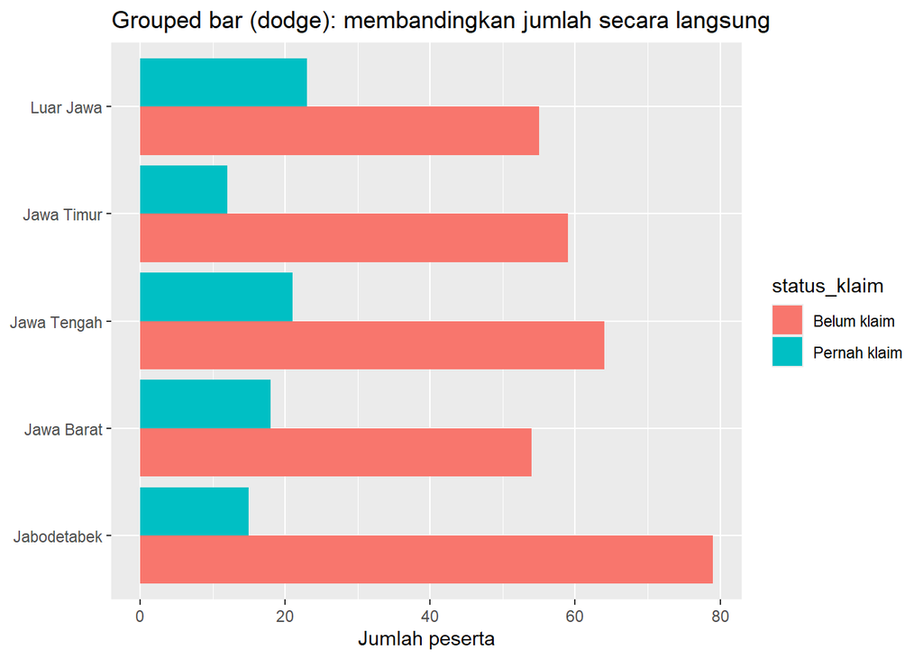

```r
ggplot(data_raw, aes(x = wilayah, fill = status_klaim)) +
  geom_bar(position = "dodge") +
  coord_flip() +
  labs(title = "Grouped bar (dodge): membandingkan jumlah secara langsung",
       x = NULL, y = "Jumlah peserta")
```

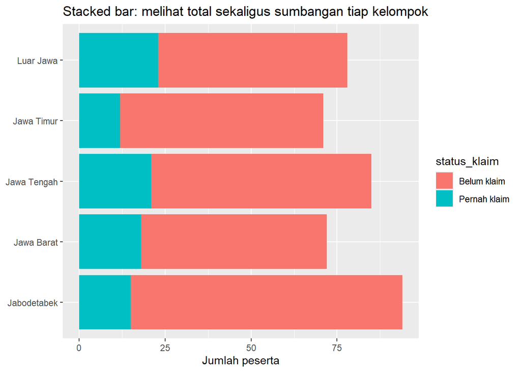

```r
ggplot(data_raw, aes(x = wilayah, fill = status_klaim)) +
  geom_bar(position = "stack") +
  coord_flip() +
  labs(title = "Stacked bar: melihat total sekaligus sumbangan tiap kelompok",
       x = NULL, y = "Jumlah peserta")
```

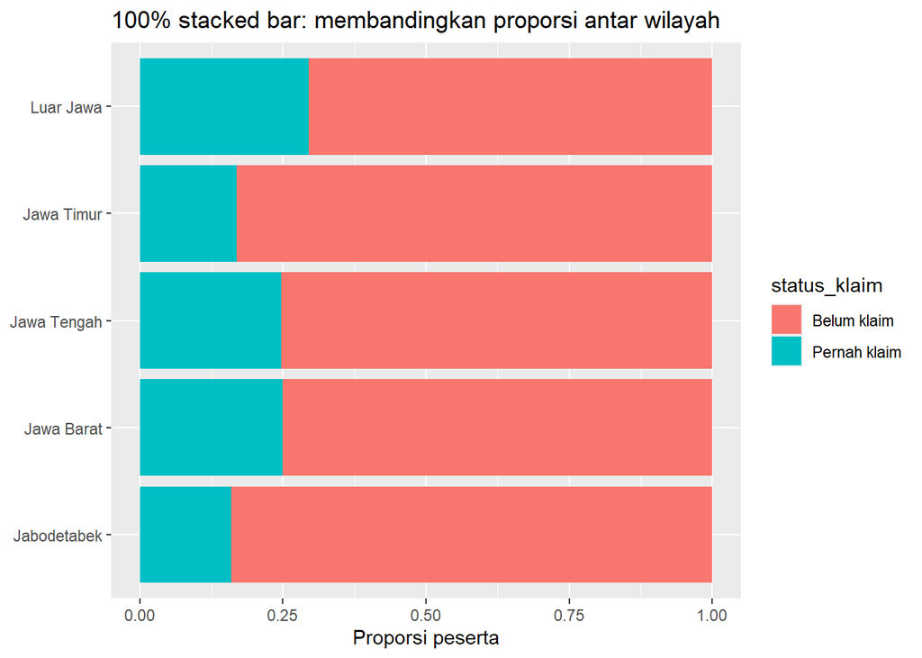

[output not shown]

```r
ggplot(data_raw, aes(x = wilayah, fill = status_klaim)) +
  geom_bar(position = "fill") +
  coord_flip() +
  labs(title = "100% stacked bar: membandingkan proporsi antar wilayah",
       x = NULL, y = "Proporsi peserta")
```

> **Catatan penting untuk `position = "fill"`:** wilayah dengan 10 peserta dan 10.000 peserta akan terlihat sama besar. Selalu sebutkan jumlah totalnya, misalnya lewat tabel `count()` pendamping.

```r
data_raw %>%
  count(wilayah, name = "jumlah_peserta")
```

```
##       wilayah jumlah_peserta
## 1 Jabodetabek             94
## 2  Jawa Barat             72
## 3 Jawa Tengah             85
## 4  Jawa Timur             71
## 5   Luar Jawa             78
```

# 13. Bivariate: Numerical × Numerical

Pertanyaan:

> Apakah jumlah kunjungan berkaitan dengan biaya klaim?

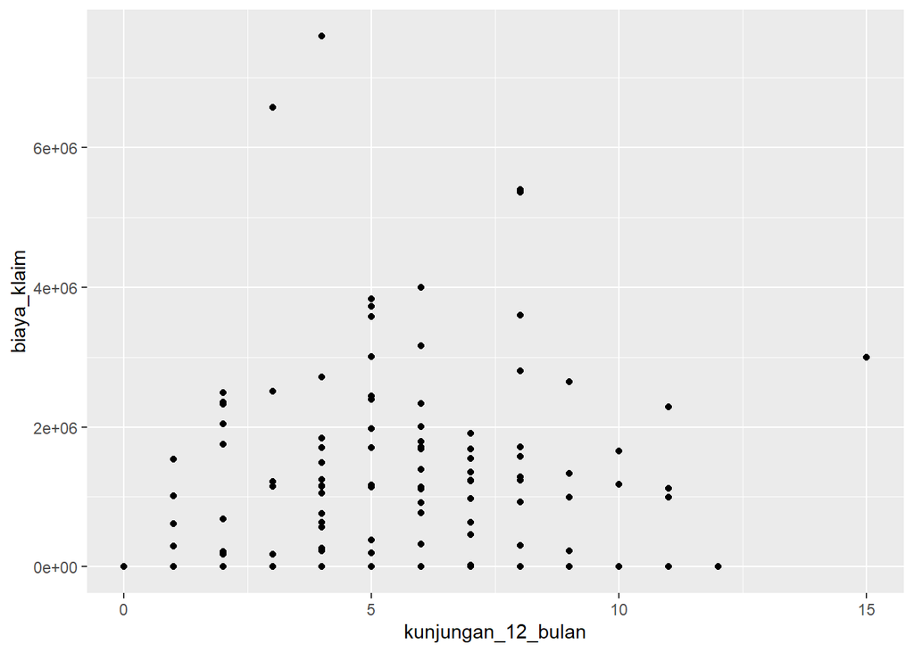

```r
ggplot(
  data_raw,
  aes(x = kunjungan_12_bulan, y = biaya_klaim)
) +
  geom_point()
```

`geom_point()` membuat scatter plot.

Scatter plot digunakan untuk melihat hubungan dua variabel numerik.

Perhatikan:

- arah hubungan;
- apakah titik cenderung membentuk pola;
- apakah hubungan kuat/lemah;
- apakah terdapat cluster;
- apakah ada observasi ekstrem.

## 13.1 Menambahkan Garis Tren dengan `geom_smooth()`

Garis tren membantu melihat arah hubungan ketika titik terlalu banyak.

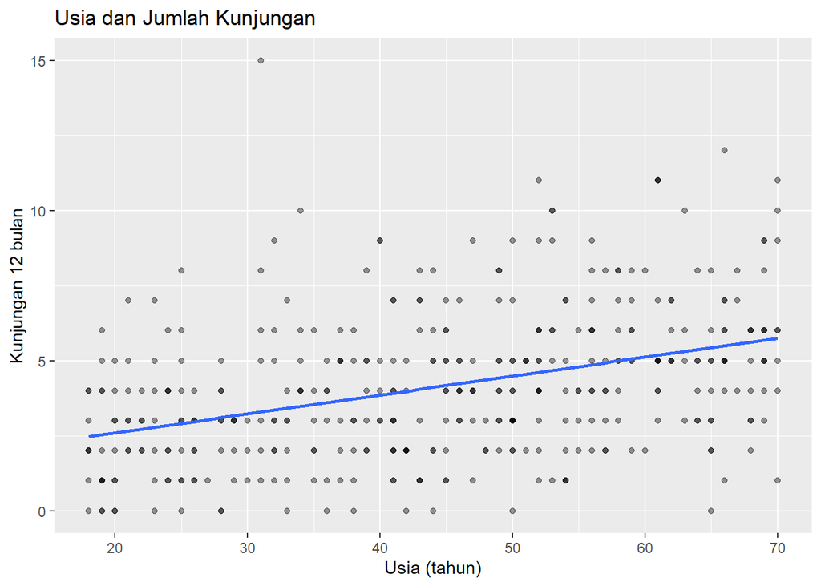

```r
ggplot(data_raw, aes(x = usia, y = kunjungan_12_bulan)) +
  geom_point(alpha = 0.4) +
  geom_smooth(method = "lm", se = FALSE) +
  labs(
    title = "Usia dan Jumlah Kunjungan",
    x = "Usia (tahun)",
    y = "Kunjungan 12 bulan"
  )
```

### Parameter yang dipakai

`method = "lm"`

→ garis tren berupa regresi linear (garis lurus).

`se = FALSE`

→ tidak menampilkan pita area kepercayaan. Gunakan `se = TRUE` bila ingin menampilkan ketidakpastiannya.

## 13.2 Mengatasi Overplotting

Ketika data banyak, titik saling menutupi sehingga kepadatan tidak terlihat.

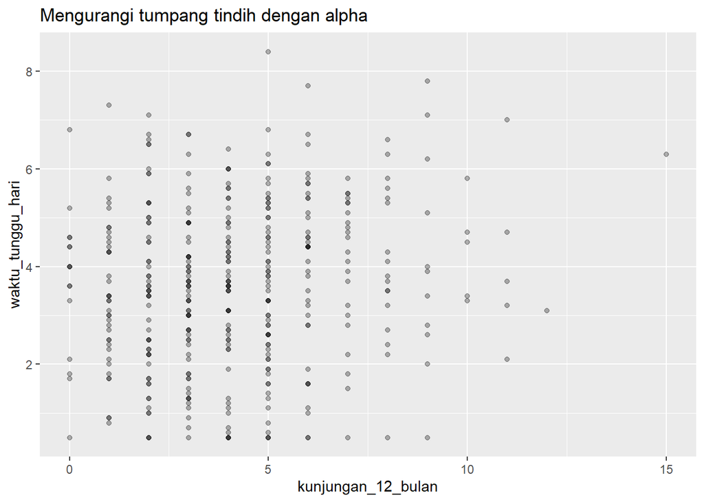

```r
ggplot(data_raw, aes(x = kunjungan_12_bulan, y = waktu_tunggu_hari)) +
  geom_point(alpha = 0.3) +
  labs(title = "Mengurangi tumpang tindih dengan alpha")
```

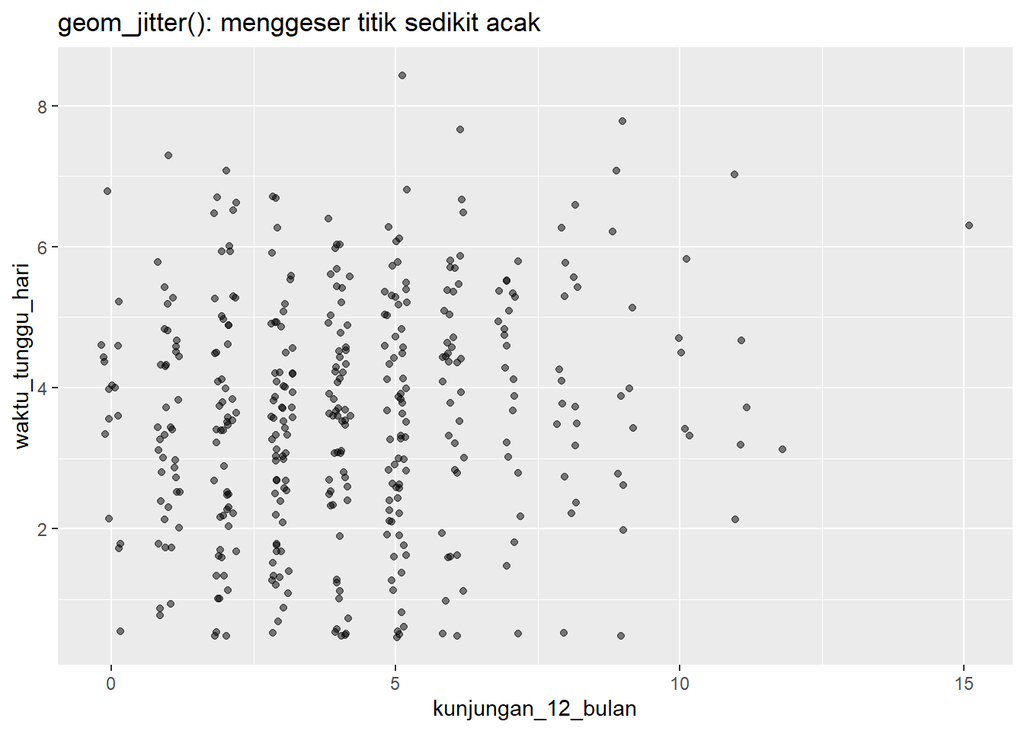

```r
ggplot(data_raw, aes(x = kunjungan_12_bulan, y = waktu_tunggu_hari)) +
  geom_jitter(width = 0.2, alpha = 0.5) +
  labs(title = "geom_jitter(): menggeser titik sedikit acak")
```

`geom_jitter()` berguna ketika salah satu variabel bernilai bulat (seperti jumlah kunjungan), sehingga banyak titik jatuh tepat di posisi yang sama.

## 13.3 Lima Hal yang Dibaca dari Scatter Plot

| Aspek | Pertanyaannya |
| --- | --- |
| **Arah** (direction) | Positif (naik ke kanan), negatif (turun ke kanan), atau tidak berpola |
| **Kekuatan** (strength) | Titik rapat mengikuti garis (kuat) atau menyebar lebar (lemah) |
| **Bentuk** (form) | Linear atau melengkung |
| **Cluster** | Adakah gumpalan terpisah yang menandakan sub-kelompok |
| **Outlier** | Adakah titik yang jauh dari kumpulan utama |

Untuk memeriksa cluster, warnai dengan variabel kategorik:

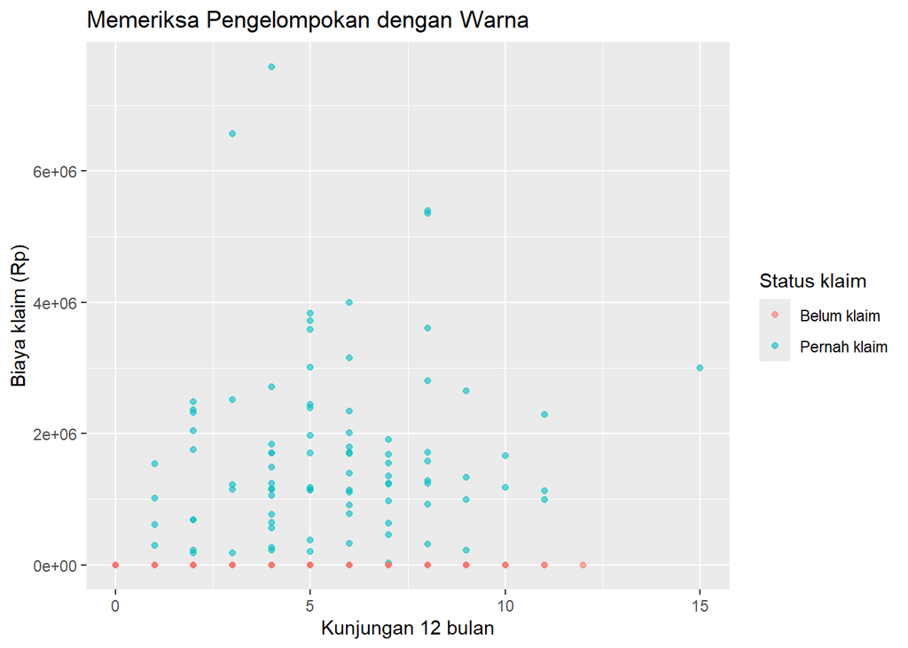

```r
ggplot(data_raw, aes(x = kunjungan_12_bulan, y = biaya_klaim, color = status_klaim)) +
  geom_point(alpha = 0.6) +
  labs(
    title = "Memeriksa Pengelompokan dengan Warna",
    x = "Kunjungan 12 bulan",
    y = "Biaya klaim (Rp)",
    color = "Status klaim"
  )
```

Terlihat bahwa peserta “Belum klaim” membentuk kelompok tersendiri di `biaya_klaim = 0`. Ini contoh cluster yang berasal dari **struktur data**, bukan dari perilaku peserta — hal seperti ini harus disebutkan dalam interpretasi.

## 13.4 Korelasi Bukan Sebab-Akibat

Ini kesalahan interpretasi paling mahal dalam analisis data. Grafik hanya menunjukkan dua variabel **bergerak bersama**, bukan bahwa yang satu menyebabkan yang lain.

Tiga penjelasan alternatif yang selalu mungkin:

| Penjelasan | Contoh |
| --- | --- |
| **Variabel ketiga** | Peserta berpenyakit kronis cenderung lebih tua **dan** lebih sering berkunjung. Usia mungkin bukan penyebabnya |
| **Arah terbalik** | Bukan kunjungan menyebabkan klaim, melainkan kondisi kesehatan mendorong keduanya |
| **Kebetulan** | Dengan cukup banyak variabel, selalu ada pasangan yang kebetulan bergerak searah |

### Cara menulis yang aman

Tulis:

> Terdapat kecenderungan jumlah kunjungan yang lebih tinggi pada peserta yang pernah mengajukan klaim.

Bukan:

> Memperbanyak kunjungan akan meningkatkan klaim.

Klaim sebab-akibat memerlukan desain analisis khusus, bukan sekadar scatter plot.

# 14. Menambahkan Kelompok dengan `color`

Pertanyaan:

> Apakah hubungan kunjungan dan biaya klaim terlihat berbeda berdasarkan status penyakit kronis?

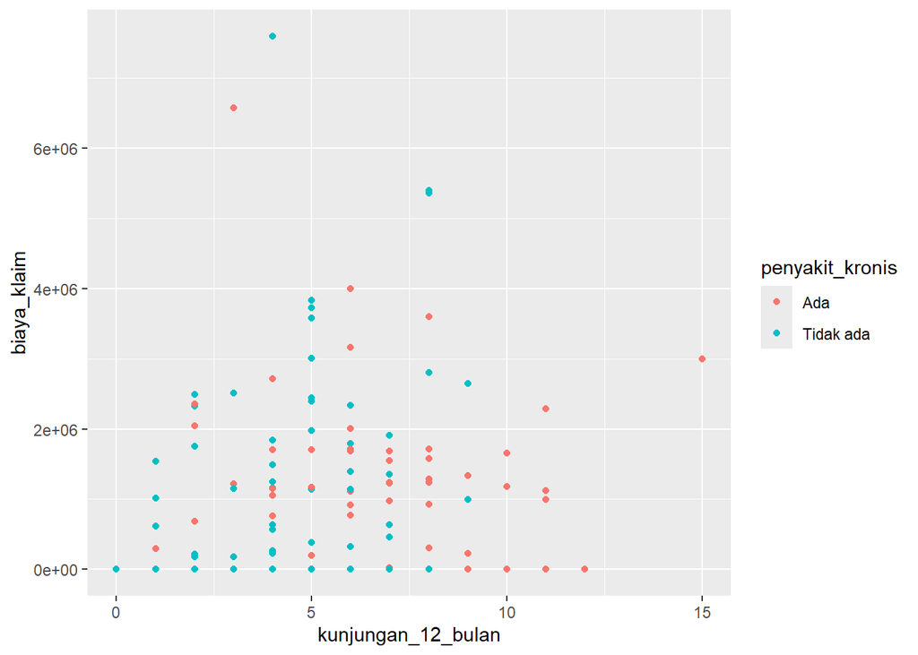

```r
ggplot(
  data_raw,
  aes(
    x = kunjungan_12_bulan,
    y = biaya_klaim,
    color = penyakit_kronis
  )
) +
  geom_point()
```

Sekarang satu grafik menampilkan:

- `kunjungan_12_bulan`;
- `biaya_klaim`;
- `penyakit_kronis`.

Ini adalah cara sederhana menampilkan lebih dari dua variabel tanpa membuat grafik terlalu kompleks.

# 15. Group Comparison

Ini sangat penting untuk soal seperti:

> “Apakah ada karakteristik tertentu yang membedakan peserta yang pernah klaim dengan yang belum?”

Kita dapat membuat beberapa visualisasi.

## 15.1 Usia

```r
ggplot(data_raw, aes(x = status_klaim, y = usia)) +
  geom_boxplot()
```

[output not shown]

## 15.2 Kunjungan

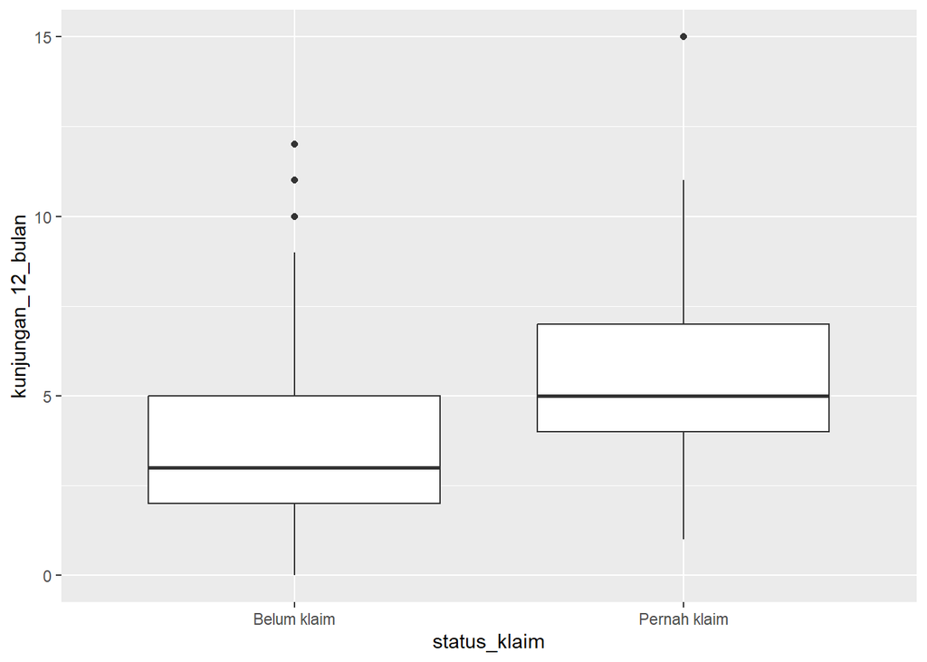

```r
ggplot(data_raw, aes(x = status_klaim, y = kunjungan_12_bulan)) +
  geom_boxplot()
```

## 15.3 Waktu tunggu

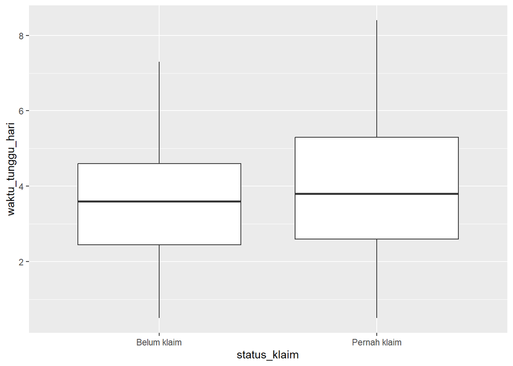

```r
ggplot(data_raw, aes(x = status_klaim, y = waktu_tunggu_hari)) +
  geom_boxplot()
```

Jangan memaksakan satu grafik untuk semua variabel.

Jika karakteristik yang diperiksa berbeda tipe, **grafiknya juga dapat berbeda**.

## 15.4 Pola yang Hilang Saat Data Diagregasi

Grafik total sering menyembunyikan perbedaan antar kelompok. Menambahkan dimensi kelompok kadang membalik kesimpulan.

Lihat rata-rata biaya klaim per wilayah tanpa pengelompokan:

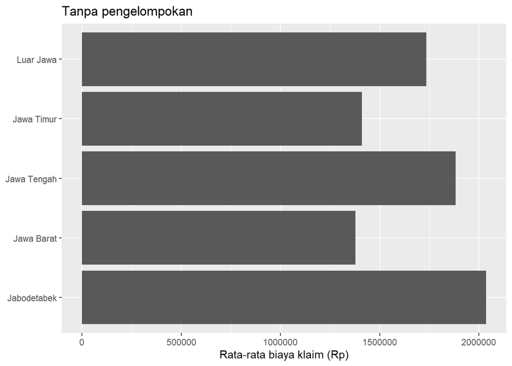

```r
data_raw %>%
  filter(status_klaim == "Pernah klaim") %>%
  group_by(wilayah) %>%
  summarise(rata_biaya = mean(biaya_klaim)) %>%
  ggplot(aes(x = wilayah, y = rata_biaya)) +
  geom_col() +
  coord_flip() +
  labs(title = "Tanpa pengelompokan", x = NULL, y = "Rata-rata biaya klaim (Rp)")
```

Sekarang pecah berdasarkan status kepesertaan:

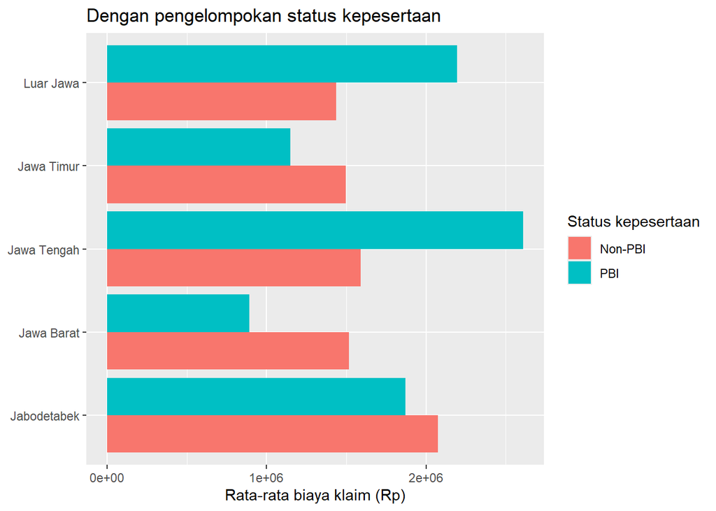

```r
data_raw %>%
  filter(status_klaim == "Pernah klaim") %>%
  group_by(wilayah, status_kepesertaan) %>%
  summarise(rata_biaya = mean(biaya_klaim), .groups = "drop") %>%
  ggplot(aes(x = wilayah, y = rata_biaya, fill = status_kepesertaan)) +
  geom_col(position = "dodge") +
  coord_flip() +
  labs(
    title = "Dengan pengelompokan status kepesertaan",
    x = NULL, y = "Rata-rata biaya klaim (Rp)", fill = "Status kepesertaan"
  )
```

> **Pelajaran:** sebelum menyimpulkan “tidak ada perbedaan”, pecah data berdasarkan kelompok yang relevan. Dua pola berlawanan yang saling meniadakan akan tampak seperti tidak ada pola sama sekali pada grafik agregat.

## 15.5 Aesthetic untuk Membedakan Kelompok

| Aesthetic | Fungsi | Cocok untuk geom |
| --- | --- | --- |
| `color` | Mewarnai garis, titik, dan garis tepi | `geom_point()`, `geom_line()` |
| `fill` | Mewarnai area isi | `geom_bar()`, `geom_col()`, `geom_boxplot()` |
| `group` | Menentukan baris mana yang satu rangkaian | `geom_line()` |
| `shape` | Membedakan lewat bentuk penanda | `geom_point()` |
| `linetype` | Membedakan lewat jenis garis | `geom_line()`, `geom_smooth()` |
| `size` | Menyatakan besaran lewat ukuran titik | `geom_point()` (bubble chart) |
| `alpha` | Mengatur transparansi | semua |

### Kesalahan umum: `color` pada bar chart

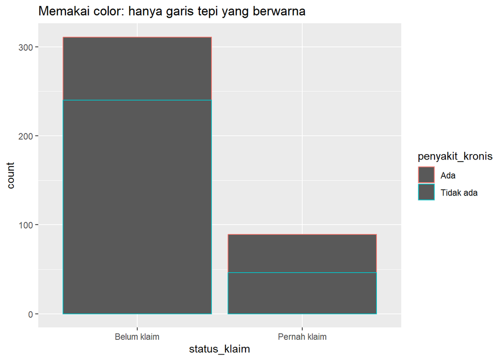

```r
# color hanya mewarnai garis tepi batang
ggplot(data_raw, aes(x = status_klaim, color = penyakit_kronis)) +
  geom_bar() +
  labs(title = "Memakai color: hanya garis tepi yang berwarna")
```

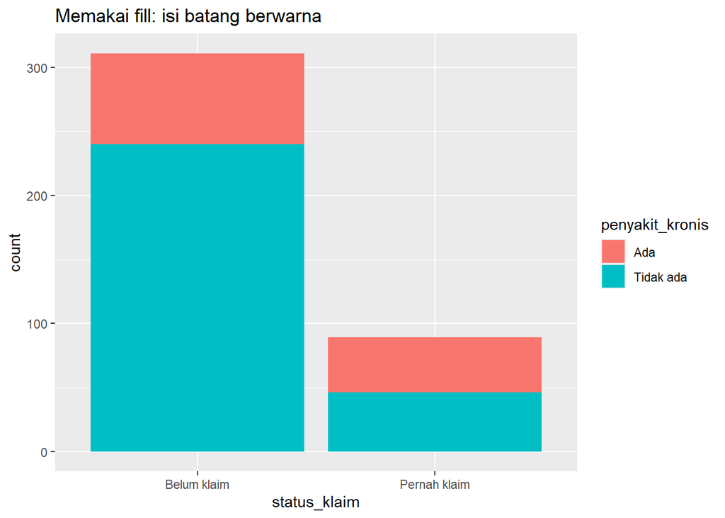

```r
# fill mewarnai isi batang - inilah yang biasanya diinginkan
ggplot(data_raw, aes(x = status_klaim, fill = penyakit_kronis)) +
  geom_bar() +
  labs(title = "Memakai fill: isi batang berwarna")
```

### Batas jumlah kategori

Gunakan maksimal **5–7 warna** dalam satu grafik. Lebih dari itu, mata pembaca harus bolak-balik ke legend dan warna berhenti menjadi informasi. Jika kelompoknya banyak, gunakan facet.

# 16. Group Comparison dengan Facet

`facet_wrap()` membuat satu grafik terpisah untuk setiap kategori.

Contoh:

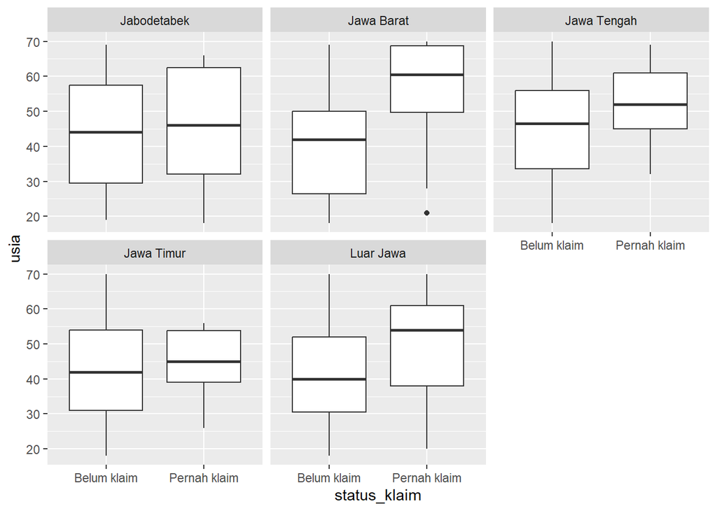

```r
ggplot(
  data_raw,
  aes(x = status_klaim, y = usia)
) +
  geom_boxplot() +
  facet_wrap(~ wilayah)
```

`facet_wrap(~ wilayah)`

artinya membuat panel terpisah untuk setiap wilayah.

Ini berguna ketika ingin melihat apakah pola klaim dan usia konsisten di beberapa wilayah.

## 16.1 `facet_wrap()` vs `facet_grid()`

| Fungsi | Memecah berdasarkan | Bentuk hasil |
| --- | --- | --- |
| `facet_wrap(~ a)` | Satu variabel | Panel berurutan, membungkus ke baris berikutnya |
| `facet_grid(a ~ b)` | Dua variabel | Matriks panel: `a` jadi baris, `b` jadi kolom |

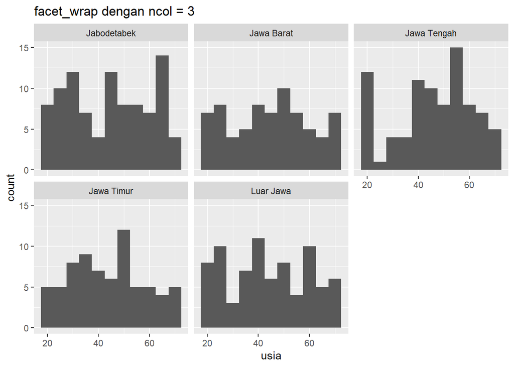

```r
ggplot(data_raw, aes(x = usia)) +
  geom_histogram(binwidth = 5) +
  facet_wrap(~ wilayah, ncol = 3) +
  labs(title = "facet_wrap dengan ncol = 3")
```

`ncol` mengatur jumlah kolom panel agar tata letaknya enak dibaca.

## 16.2 Catatan Penting: `scales = "free"`

Secara default semua panel memakai **sumbu yang sama**, sehingga besaran antar kelompok dapat dibandingkan langsung. Inilah yang biasanya diinginkan.

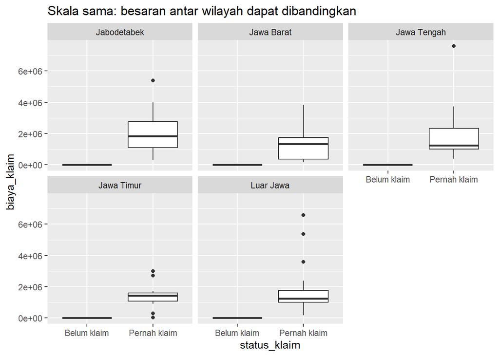

```r
ggplot(data_raw, aes(x = status_klaim, y = biaya_klaim)) +
  geom_boxplot() +
  facet_wrap(~ wilayah) +
  labs(title = "Skala sama: besaran antar wilayah dapat dibandingkan")
```

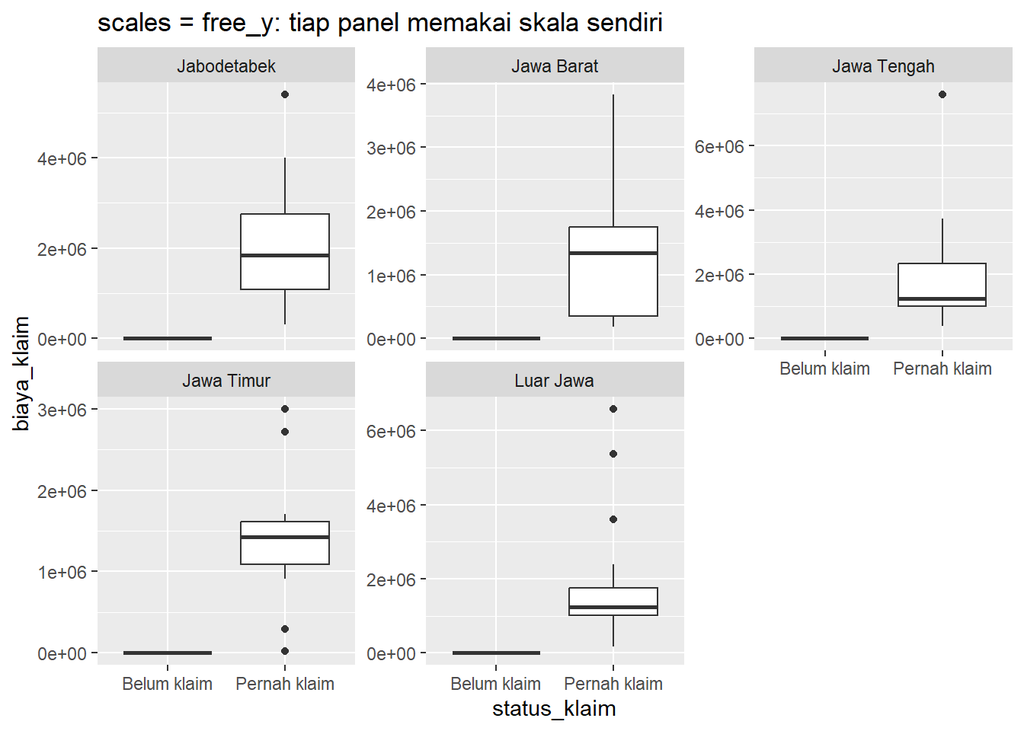

```r
ggplot(data_raw, aes(x = status_klaim, y = biaya_klaim)) +
  geom_boxplot() +
  facet_wrap(~ wilayah, scales = "free_y") +
  labs(title = "scales = free_y: tiap panel memakai skala sendiri")
```

Dengan `scales = "free_y"`, bentuk pola pada kelompok kecil menjadi terlihat, tetapi **perbandingan besaran antar panel tidak lagi sah**.

Gunakan hanya bila yang ingin dibandingkan adalah **bentuk pola**, bukan besarnya nilai — dan sebutkan hal itu dalam interpretasi.

## 16.3 Kapan Facet, Kapan Warna?

| Gunakan **warna** bila | Gunakan **facet** bila |
| --- | --- |
| Kelompok hanya 2–5 | Kelompok lebih dari 5 |
| Ingin membandingkan nilai secara presisi | Garis atau titik saling menutupi |
| Butuh grafik ringkas dalam satu panel | Ingin melihat bentuk pola tiap kelompok secara utuh |

Keduanya dapat dipakai bersama ketika ada dua dimensi pengelompokan:

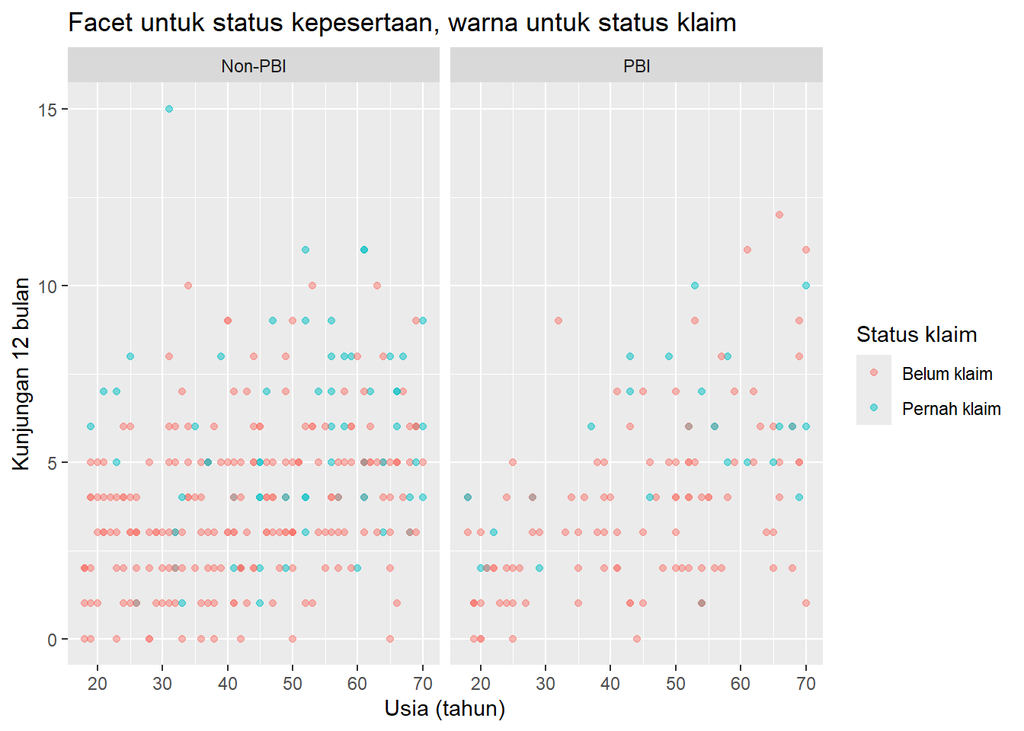

```r
ggplot(data_raw, aes(x = usia, y = kunjungan_12_bulan, color = status_klaim)) +
  geom_point(alpha = 0.5) +
  facet_wrap(~ status_kepesertaan) +
  labs(
    title = "Facet untuk status kepesertaan, warna untuk status klaim",
    x = "Usia (tahun)", y = "Kunjungan 12 bulan", color = "Status klaim"
  )
```

# 17. Customization Dasar

Grafik yang baik bukan hanya grafik yang benar, tetapi juga mudah dipahami.

## 17.1 Judul dan label

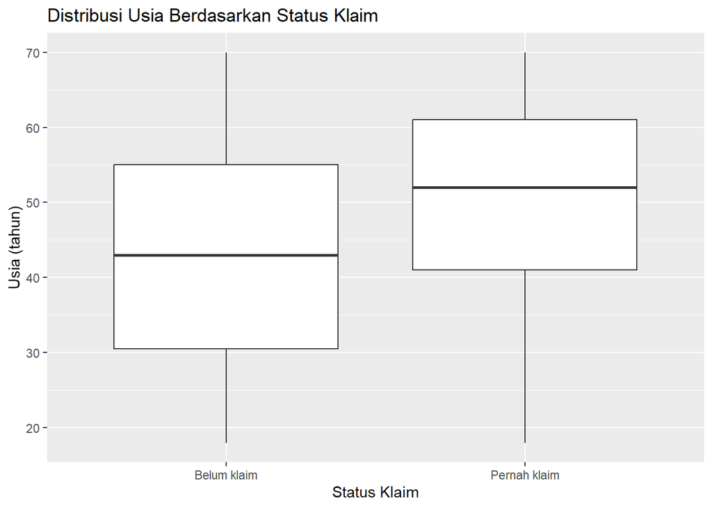

```r
ggplot(
  data_raw,
  aes(x = status_klaim, y = usia)
) +
  geom_boxplot() +
  labs(
    title = "Distribusi Usia Berdasarkan Status Klaim",
    x = "Status Klaim",
    y = "Usia (tahun)"
  )
```

### `labs()`

Digunakan untuk memberi label pada grafik.

- `title` → judul;
- `x` → label sumbu X;
- `y` → label sumbu Y.

## 17.2 Theme

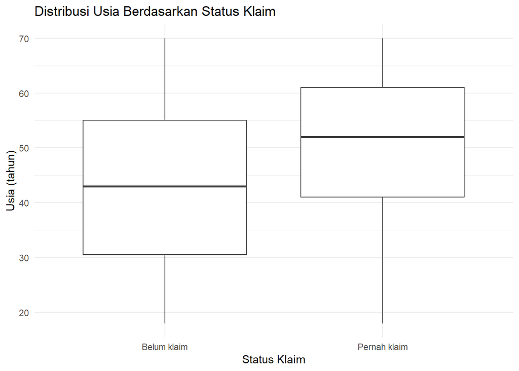

```r
ggplot(
  data_raw,
  aes(x = status_klaim, y = usia)
) +
  geom_boxplot() +
  labs(
    title = "Distribusi Usia Berdasarkan Status Klaim",
    x = "Status Klaim",
    y = "Usia (tahun)"
  ) +
  theme_minimal()
```

`theme_minimal()` mengatur tampilan dasar grafik.

Untuk ujian, jangan terlalu fokus pada dekorasi. **Kejelasan informasi lebih penting daripada estetika.**

## 17.3 Menulis Judul yang Berisi Temuan

Judul yang baik menyatakan **temuan**, bukan sekadar nama variabel.

| Kurang baik | Lebih baik |
| --- | --- |
| “Grafik Usia dan Status Klaim” | “Peserta yang Pernah Klaim Cenderung Berusia Lebih Tua” |
| “Distribusi Waktu Tunggu” | “Sebagian Besar Peserta Menunggu 3–6 Hari” |

Gunakan `subtitle` untuk konteks pembatas dan `caption` untuk sumber data.

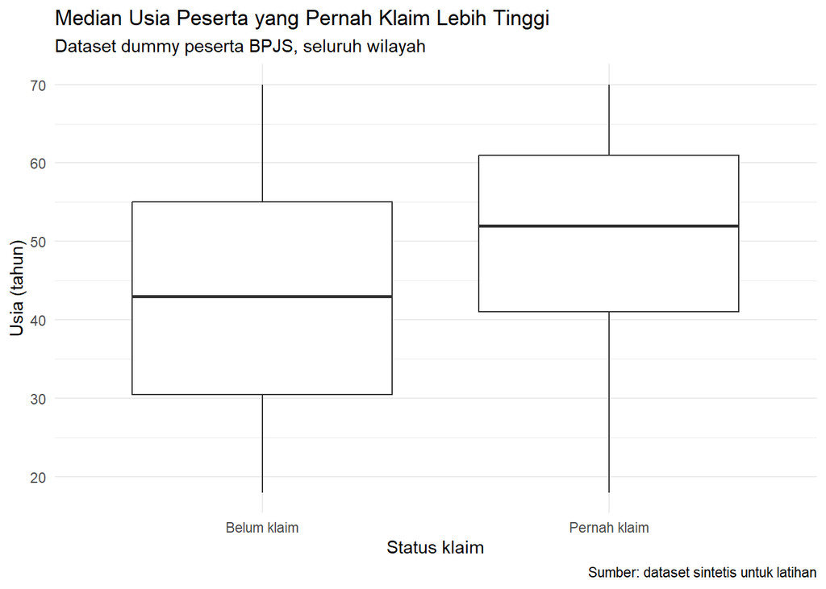

```r
ggplot(data_raw, aes(x = status_klaim, y = usia)) +
  geom_boxplot() +
  labs(
    title = "Median Usia Peserta yang Pernah Klaim Lebih Tinggi",
    subtitle = "Dataset dummy peserta BPJS, seluruh wilayah",
    x = "Status klaim",
    y = "Usia (tahun)",
    caption = "Sumber: dataset sintetis untuk latihan"
  ) +
  theme_minimal()
```

## 17.4 Anotasi dan Garis Bantu

Anotasi menyorot informasi penting agar pembaca tidak perlu menebak nilai dari gridline.

### Garis ambang batas dengan `geom_hline()`

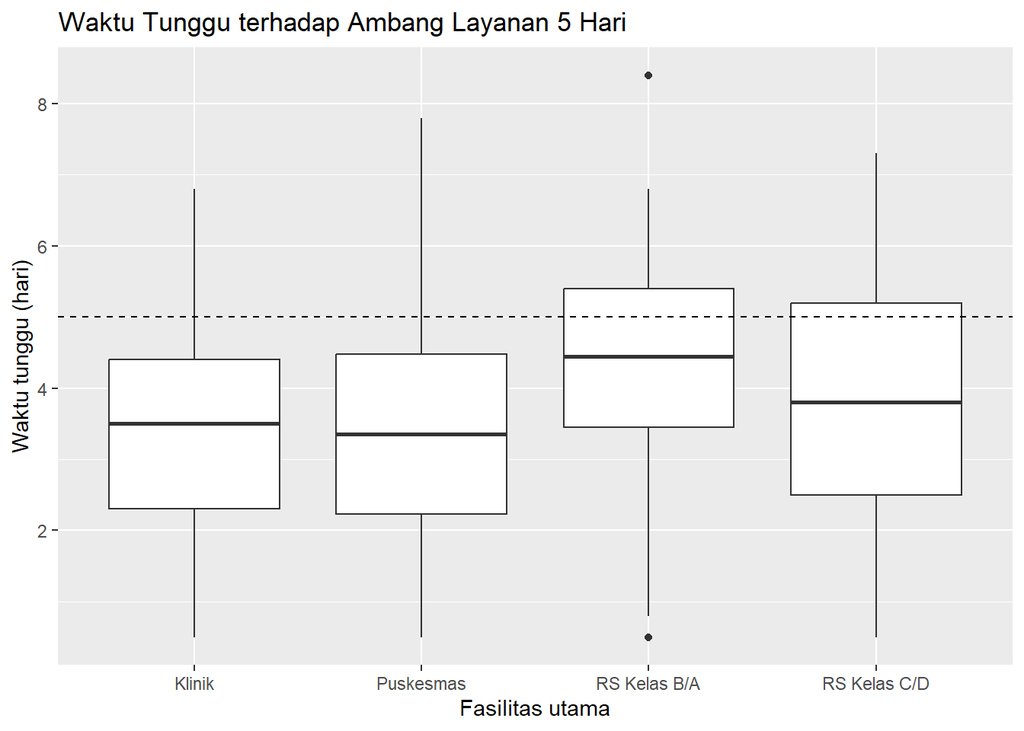

```r
ggplot(data_raw, aes(x = fasilitas_utama, y = waktu_tunggu_hari)) +
  geom_boxplot() +
  geom_hline(yintercept = 5, linetype = "dashed") +
  labs(
    title = "Waktu Tunggu terhadap Ambang Layanan 5 Hari",
    x = "Fasilitas utama",
    y = "Waktu tunggu (hari)"
  )
```

`geom_hline(yintercept = 5)` menggambar garis horizontal pada nilai 5. Padanannya `geom_vline(xintercept = ...)` untuk garis vertikal.

### Menambahkan teks dengan `annotate()`

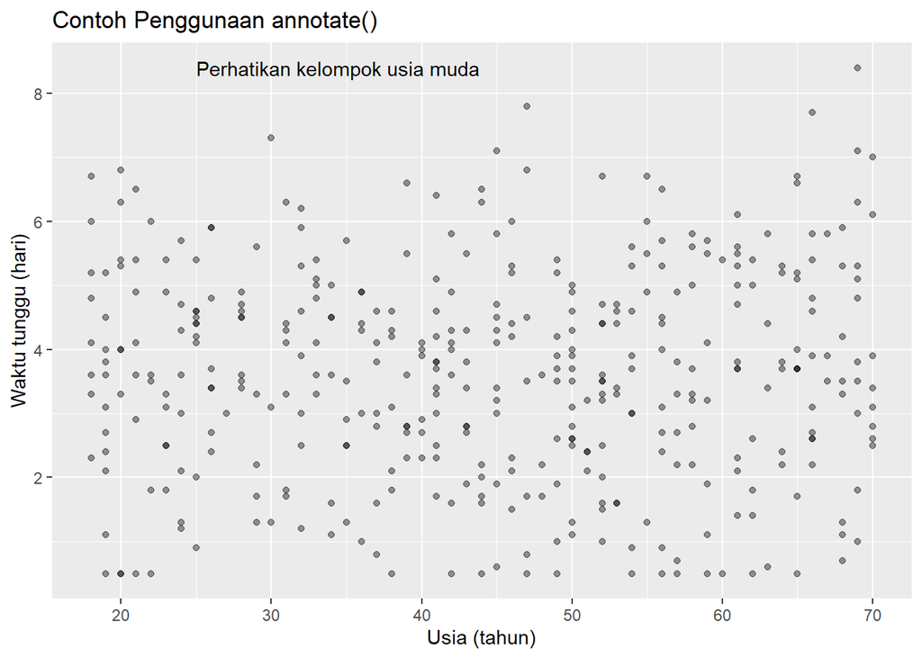

```r
ggplot(data_raw, aes(x = usia, y = waktu_tunggu_hari)) +
  geom_point(alpha = 0.4) +
  annotate("text", x = 25, y = max(data_raw$waktu_tunggu_hari),
           label = "Perhatikan kelompok usia muda", hjust = 0) +
  labs(title = "Contoh Penggunaan annotate()",
       x = "Usia (tahun)", y = "Waktu tunggu (hari)")
```

### Menampilkan nilai langsung dengan `geom_text()`

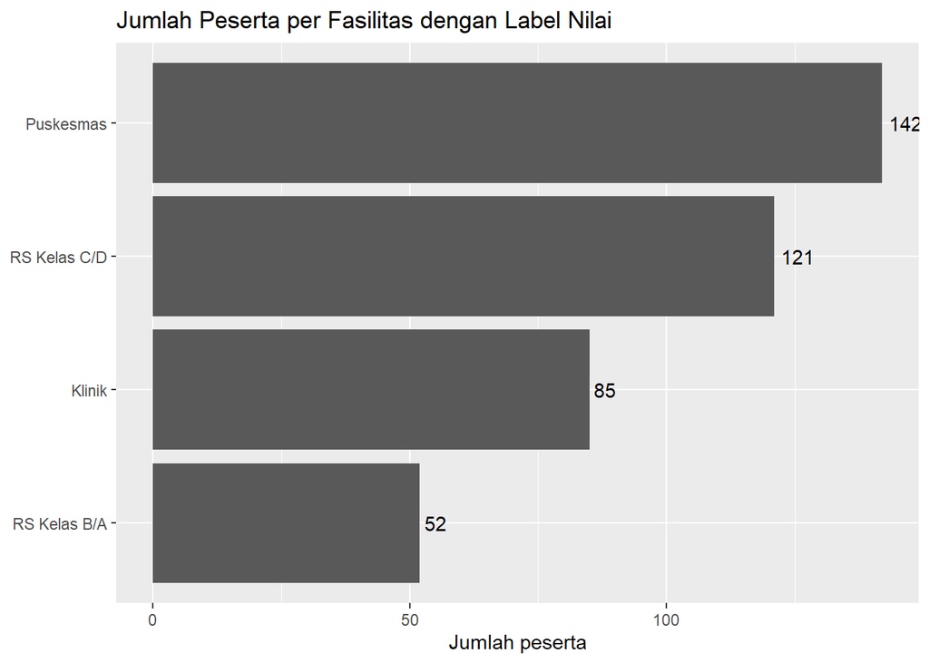

```r
data_raw %>%
  count(fasilitas_utama) %>%
  ggplot(aes(x = reorder(fasilitas_utama, n), y = n)) +
  geom_col() +
  geom_text(aes(label = n), hjust = -0.2) +
  coord_flip() +
  labs(title = "Jumlah Peserta per Fasilitas dengan Label Nilai",
       x = NULL, y = "Jumlah peserta")
```

Untuk grafik dengan sedikit kategori, menuliskan nilai langsung lebih efektif daripada mengandalkan gridline.

## 17.5 Menyorot Satu Kategori

Beri warna mencolok hanya pada kategori yang ingin disorot, sisanya abu-abu. Mata pembaca langsung tertuju ke pesan utama.

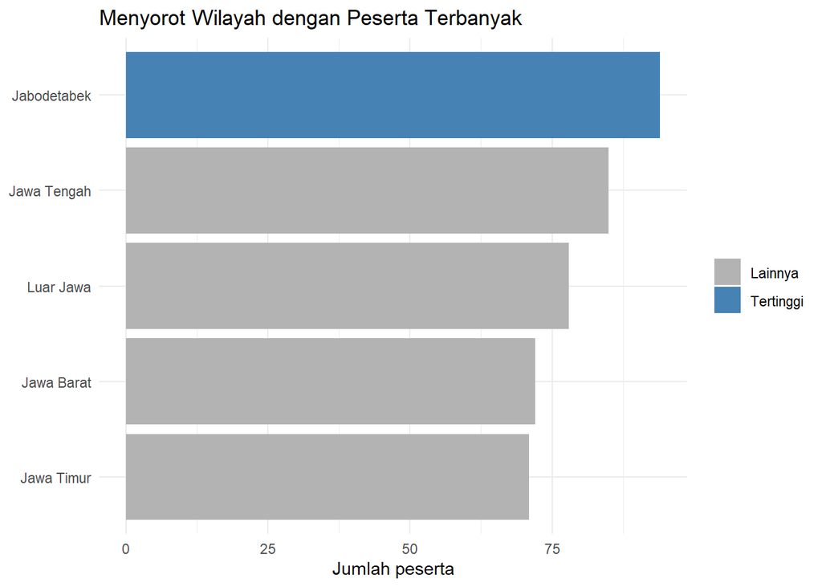

```r
data_raw %>%
  count(wilayah) %>%
  mutate(sorot = ifelse(n == max(n), "Tertinggi", "Lainnya")) %>%
  ggplot(aes(x = reorder(wilayah, n), y = n, fill = sorot)) +
  geom_col() +
  scale_fill_manual(values = c("Tertinggi" = "steelblue", "Lainnya" = "grey70")) +
  coord_flip() +
  labs(
    title = "Menyorot Wilayah dengan Peserta Terbanyak",
    x = NULL, y = "Jumlah peserta", fill = NULL
  ) +
  theme_minimal()
```

`scale_fill_manual()` menentukan warna secara manual untuk tiap nilai kategori.

## 17.6 Menyimpan Grafik dengan `ggsave()`

```r
ggsave("grafik_usia_klaim.png", width = 8, height = 5, dpi = 300)
```

| Parameter | Fungsi |
| --- | --- |
| nama file | Format ditentukan dari ekstensinya: `.png`, `.jpg`, `.pdf`, `.svg` |
| `width`, `height` | Ukuran dalam inci; tentukan di sini agar ukuran teks konsisten |
| `dpi` | Resolusi; gunakan 300 untuk kebutuhan cetak |

`ggsave()` menyimpan grafik **terakhir** yang dibuat. Jangan mengubah ukuran gambar setelah diekspor, karena teksnya akan ikut melar atau mengecil.

# 18. Jenis Visualisasi Lain

Sampai bagian sebelumnya kita banyak menggunakan bar chart, histogram, boxplot, dan scatter plot. Pada bagian ini kita mengenal beberapa grafik lain yang juga dapat muncul dalam kebutuhan analisis.

Pemilihan grafik tetap harus dimulai dari **pertanyaan analisis**, bukan dari keinginan menggunakan grafik tertentu.

## 18.1 Line Chart

Line chart cocok ketika sumbu X memiliki **urutan**, terutama waktu.

Contoh pertanyaan:

> Bagaimana jumlah kunjungan berubah dari bulan ke bulan?

Kita ringkas dulu jumlah kunjungan berdasarkan bulan.

```r
monthly_visits <- data_raw %>%
  group_by(tahun_bulan) %>%
  summarise(
    jumlah_kunjungan = sum(kunjungan_12_bulan)
  )

monthly_visits
```

```
## # A tibble: 12 × 2
##    tahun_bulan jumlah_kunjungan
##    <chr>                  <int>
##  1 2025-01                  184
##  2 2025-02                  124
##  3 2025-03                  150
##  4 2025-04                  140
##  5 2025-05                  122
##  6 2025-06                  116
##  7 2025-07                  135
##  8 2025-08                  158
##  9 2025-09                  134
## 10 2025-10                   92
## 11 2025-11                  119
## 12 2025-12                  183
```

Kemudian buat line chart:

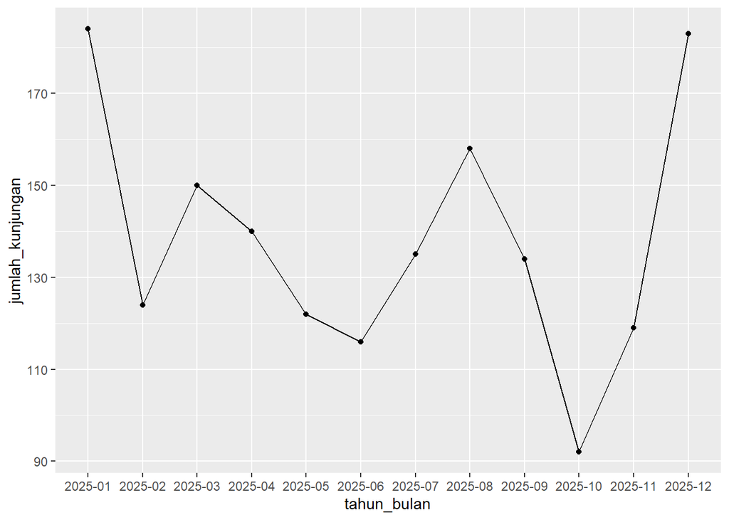

```r
ggplot(
  monthly_visits,
  aes(x = tahun_bulan, y = jumlah_kunjungan, group = 1)
) +
  geom_line() +
  geom_point()
```

### Fungsi `geom_line()`

Menghubungkan titik-titik secara berurutan.

### Fungsi `geom_point()`

Menampilkan titik observasi pada setiap periode.

Keduanya sering digunakan bersama agar tren dan titik pengamatan mudah dibaca.

### Kapan menggunakan line chart?

Gunakan ketika:

- X mempunyai urutan alami;
- terutama waktu;
- kita ingin melihat **tren/perubahan**.

Contoh:

- jumlah kunjungan per bulan;
- jumlah klaim per bulan;
- biaya klaim per bulan.

Jangan menggunakan line chart hanya karena kategorinya banyak. Jika kategori tidak memiliki urutan alami, bar chart biasanya lebih tepat.

## 18.2 Line Chart dengan Kelompok

Pertanyaan:

> Bagaimana jumlah klaim berubah dari bulan ke bulan berdasarkan status klaim?

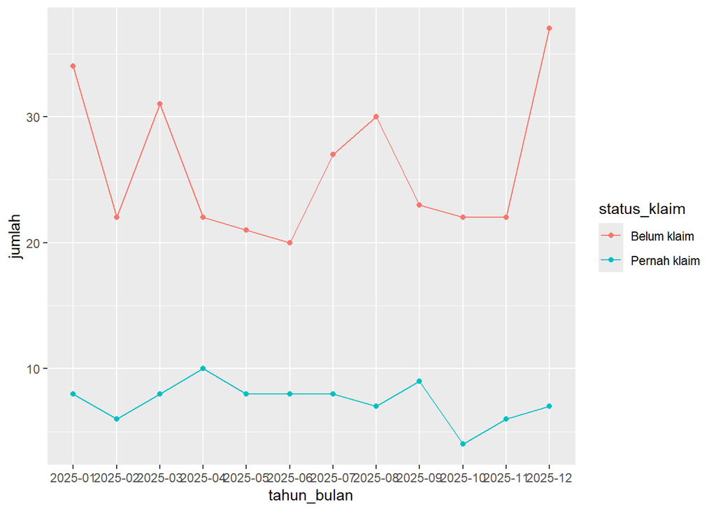

```r
monthly_claim <- data_raw %>%
  group_by(tahun_bulan, status_klaim) %>%
  summarise(
    jumlah = n(),
    .groups = "drop"
  )

ggplot(
  monthly_claim,
  aes(
    x = tahun_bulan,
    y = jumlah,
    color = status_klaim,
    group = status_klaim
  )
) +
  geom_line() +
  geom_point()
```

Di sini:

- `color` → membedakan kelompok;
- `group` → memberi tahu `ggplot2` garis mana yang harus dihubungkan.

## 18.3 Pie Chart

Pie chart digunakan untuk menunjukkan **bagian dari satu keseluruhan**.

Contoh:

> Bagaimana komposisi jenis layanan?

Kita buat ringkasan terlebih dahulu:

```r
service_summary <- data_raw %>%
  count(jenis_layanan)

service_summary
```

```
##   jenis_layanan   n
## 1          Obat 106
## 2   Pemeriksaan  52
## 3    Rawat Inap  71
## 4   Rawat Jalan 171
```

Kemudian:

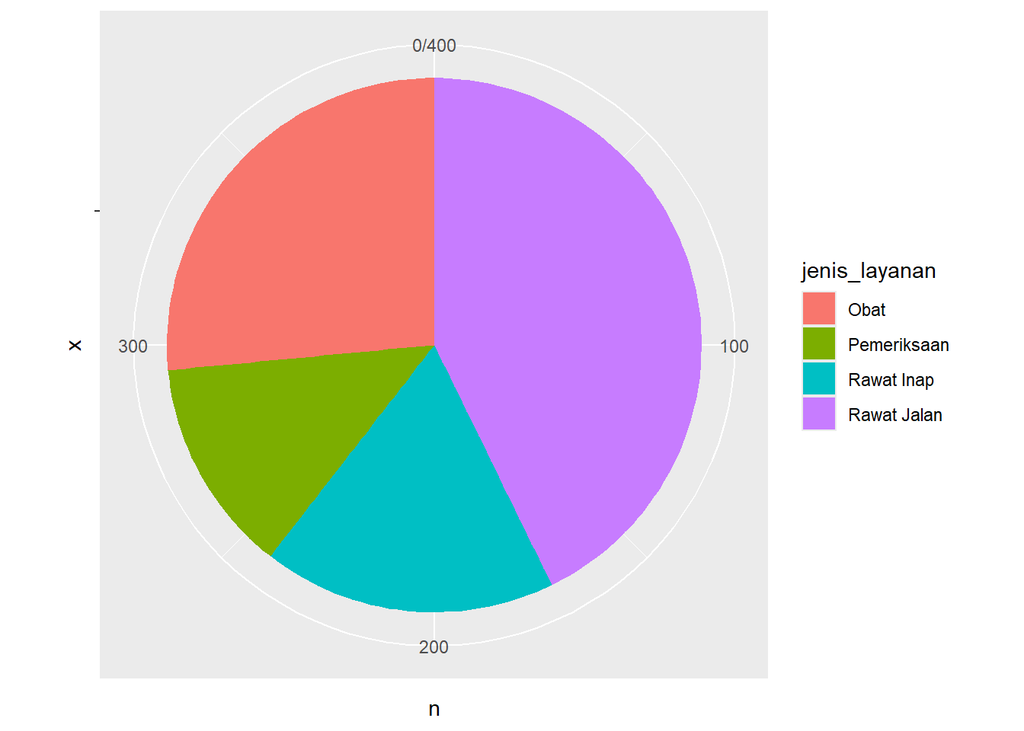

```r
ggplot(
  service_summary,
  aes(
    x = "",
    y = n,
    fill = jenis_layanan
  )
) +
  geom_col() +
  coord_polar(theta = "y")
```

### Apa fungsi `coord_polar()`?

`coord_polar()` mengubah koordinat Cartesian menjadi koordinat polar.

Dengan:

```r
theta = "y"
```

nilai pada sumbu Y digunakan sebagai besar sudut, sehingga bar berubah menjadi pie chart.

### Kapan pie chart cocok?

Pie chart cocok jika:

- ingin menunjukkan **komposisi**;
- semua kategori merupakan bagian dari satu keseluruhan;
- jumlah kategori tidak terlalu banyak.

Untuk membandingkan kategori dengan sangat presisi, bar chart biasanya lebih mudah dibaca.

## 18.4 Bar Chart sebagai Alternatif Pie Chart

Komposisi yang sama dapat dibuat dengan bar chart:

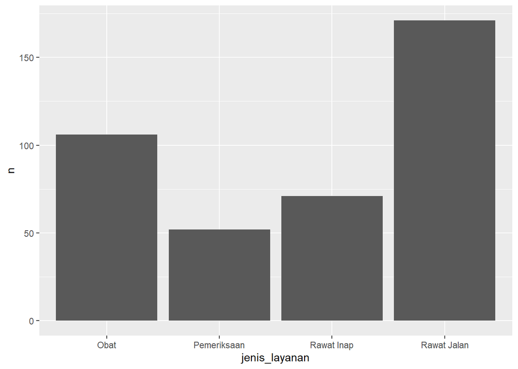

```r
ggplot(
  service_summary,
  aes(
    x = jenis_layanan,
    y = n
  )
) +
  geom_col()
```

Perhatikan bahwa bar chart lebih mudah digunakan untuk membandingkan tinggi masing-masing kategori.

## 18.5 Density Plot

Density plot dapat digunakan untuk melihat bentuk distribusi variabel numerik secara lebih halus.

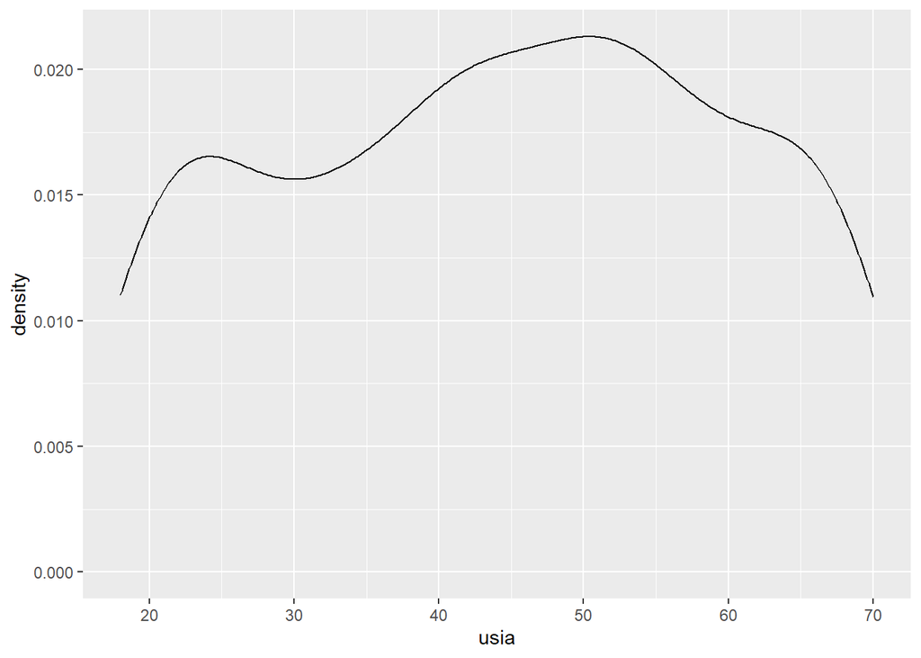

```r
ggplot(
  data_raw,
  aes(x = usia)
) +
  geom_density()
```

Untuk membandingkan distribusi berdasarkan status klaim:

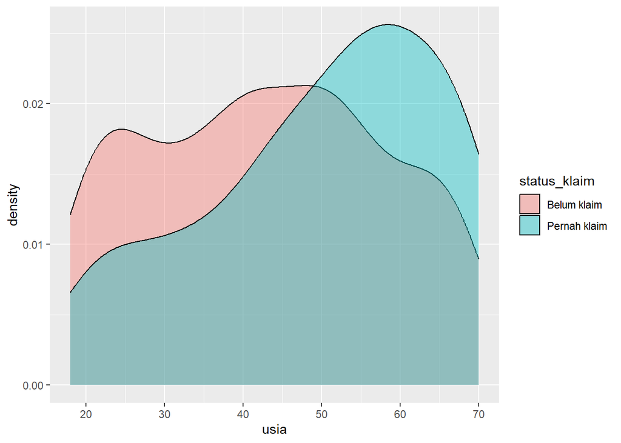

```r
ggplot(
  data_raw,
  aes(
    x = usia,
    fill = status_klaim
  )
) +
  geom_density(alpha = 0.4)
```

### Parameter `alpha`

`alpha` mengatur transparansi.

Nilai lebih kecil:

```r
alpha = 0.4
```

→ lebih transparan.

Ini berguna ketika beberapa distribusi ditampilkan bersamaan.

## 18.6 Area Chart

Area chart dapat digunakan untuk menampilkan perubahan nilai sepanjang waktu dengan area di bawah garis.

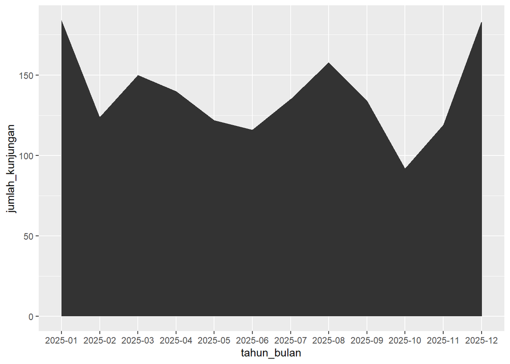

```r
ggplot(
  monthly_visits,
  aes(
    x = tahun_bulan,
    y = jumlah_kunjungan,
    group = 1
  )
) +
  geom_area()
```

Untuk kebutuhan PAI, line chart biasanya lebih mudah dibaca. Area chart cukup dipahami sebagai alternatif ketika ingin menekankan besarnya nilai sepanjang waktu.

## 18.7 Memilih Jenis Grafik

Gunakan tabel berikut sebagai panduan:

| Tujuan | Grafik yang sesuai |
| --- | --- |
| Membandingkan jumlah kategori | Bar chart |
| Membandingkan proporsi kategori | Bar / 100% stacked bar |
| Menunjukkan komposisi sederhana | Pie chart |
| Melihat distribusi numerik | Histogram / density plot |
| Membandingkan distribusi antar kelompok | Boxplot |
| Melihat hubungan dua numerik | Scatter plot |
| Melihat perubahan dari waktu ke waktu | Line chart |
| Menunjukkan pola nilai sepanjang waktu dengan area | Area chart |

> **Catatan penting:** tidak ada grafik yang selalu paling baik. Grafik dipilih berdasarkan pertanyaan dan struktur data.

# 19. Eksplorasi Parameter `ggplot2`

Setelah dapat membuat grafik, langkah berikutnya adalah memahami parameter yang sering berguna.

Kita tidak perlu menghafalkan semua parameter `ggplot2`. Fokus pada parameter yang paling mungkin membantu dalam pekerjaan analisis dan ujian.

## 19.1 `color`

Digunakan untuk warna garis atau outline berdasarkan variabel.

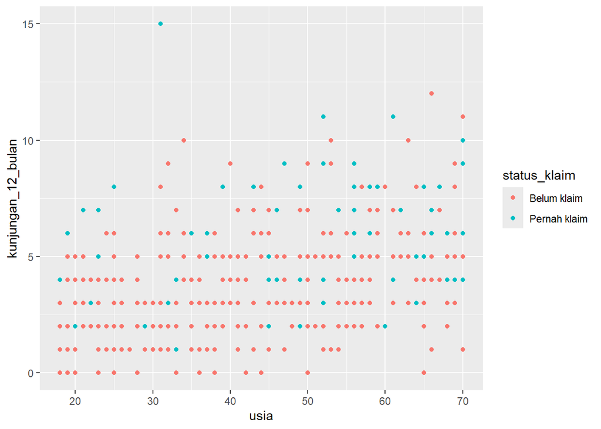

```r
ggplot(
  data_raw,
  aes(
    x = usia,
    y = kunjungan_12_bulan,
    color = status_klaim
  )
) +
  geom_point()
```

Di sini warna ditentukan oleh data.

## 19.2 `fill`

Digunakan untuk mengisi bagian dalam objek seperti bar dan boxplot.

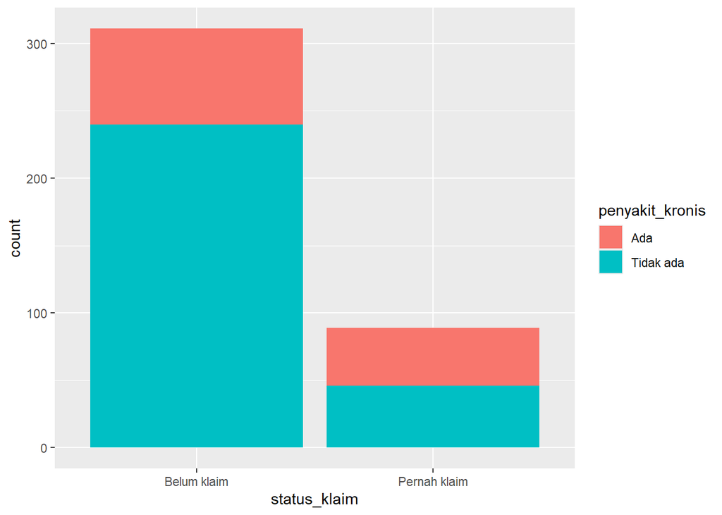

```r
ggplot(
  data_raw,
  aes(
    x = status_klaim,
    fill = penyakit_kronis
  )
) +
  geom_bar()
```

### Perbedaan sederhana

`color`

→ warna garis/outline.

`fill`

→ warna bagian dalam.

## 19.3 `alpha`

Mengatur transparansi.

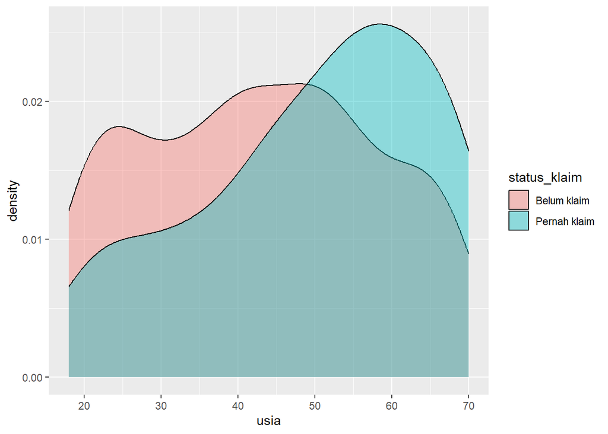

```r
ggplot(
  data_raw,
  aes(
    x = usia,
    fill = status_klaim
  )
) +
  geom_density(alpha = 0.4)
```

`alpha = 1`

→ tidak transparan.

`alpha = 0`

→ sepenuhnya transparan.

Biasanya gunakan nilai di antara 0 dan 1.

## 19.4 `size` dan `linewidth`

Untuk titik:

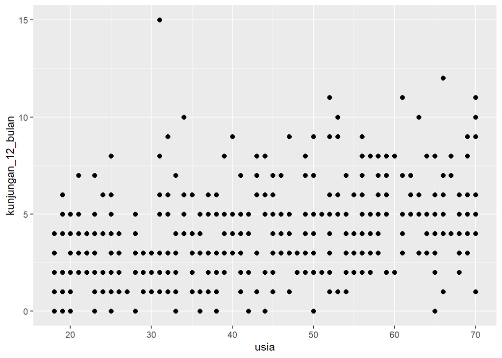

```r
ggplot(
  data_raw,
  aes(
    x = usia,
    y = kunjungan_12_bulan
  )
) +
  geom_point(size = 2)
```

`size` mengatur ukuran titik.

Untuk garis, gunakan `linewidth`:

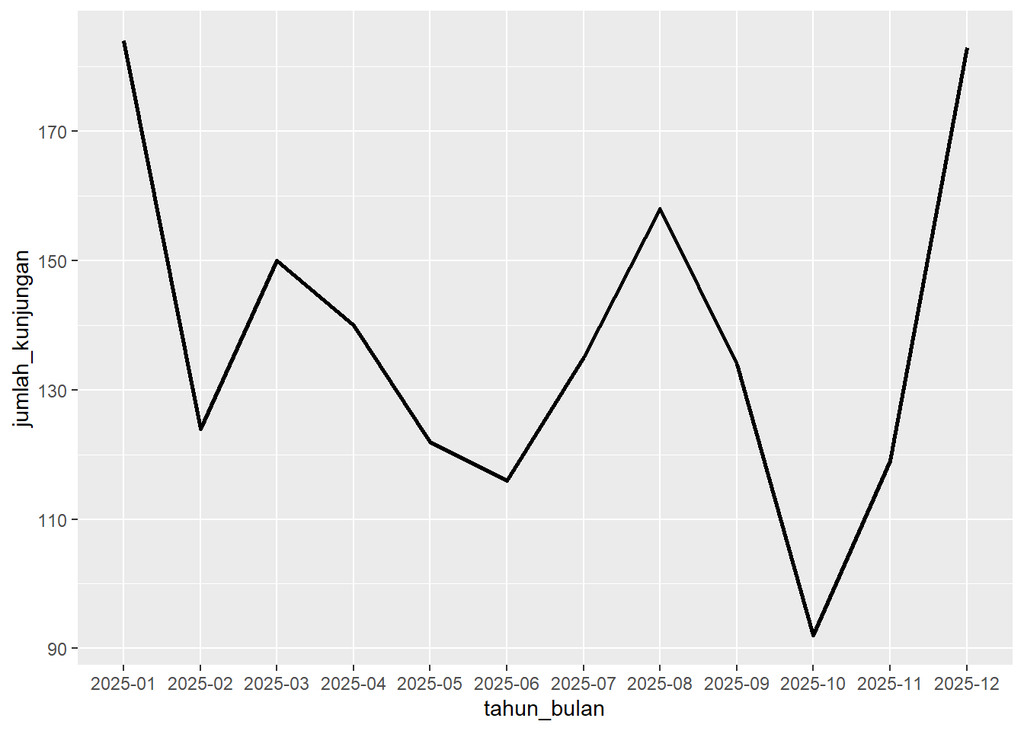

```r
ggplot(
  monthly_visits,
  aes(
    x = tahun_bulan,
    y = jumlah_kunjungan,
    group = 1
  )
) +
  geom_line(linewidth = 1)
```

## 19.5 `shape`

Digunakan untuk membedakan kelompok berdasarkan bentuk titik.

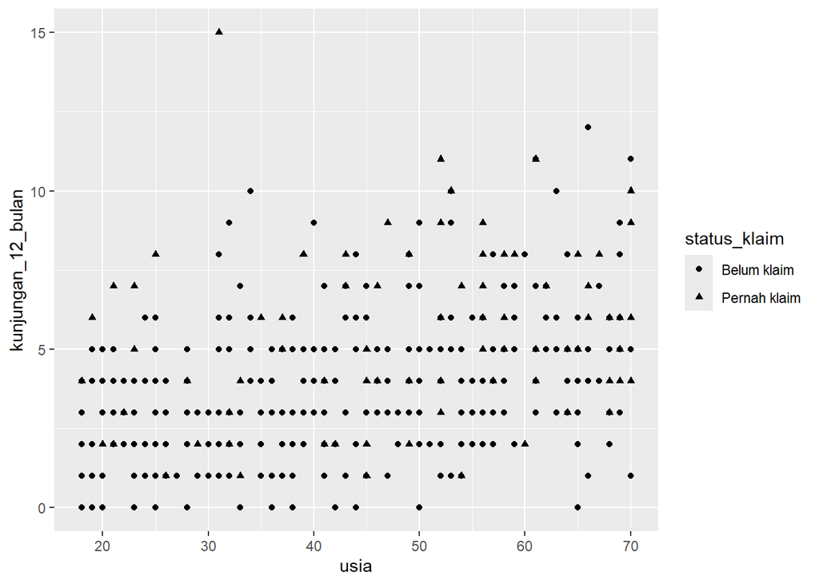

```r
ggplot(
  data_raw,
  aes(
    x = usia,
    y = kunjungan_12_bulan,
    shape = status_klaim
  )
) +
  geom_point()
```

`shape` sangat berguna ketika ingin membedakan kelompok tanpa mengandalkan warna.

## 19.6 `position`

Sangat berguna untuk bar chart.

### `position = "stack"`

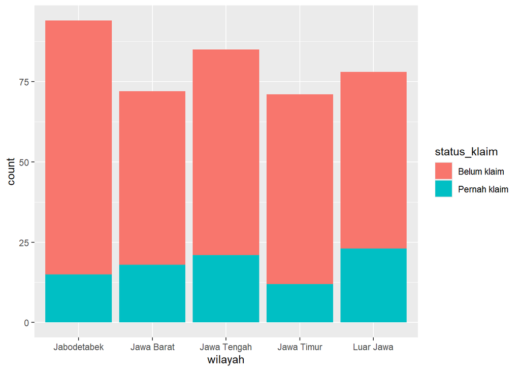

```r
ggplot(
  data_raw,
  aes(
    x = wilayah,
    fill = status_klaim
  )
) +
  geom_bar(position = "stack")
```

Kategori ditumpuk.

### `position = "dodge"`

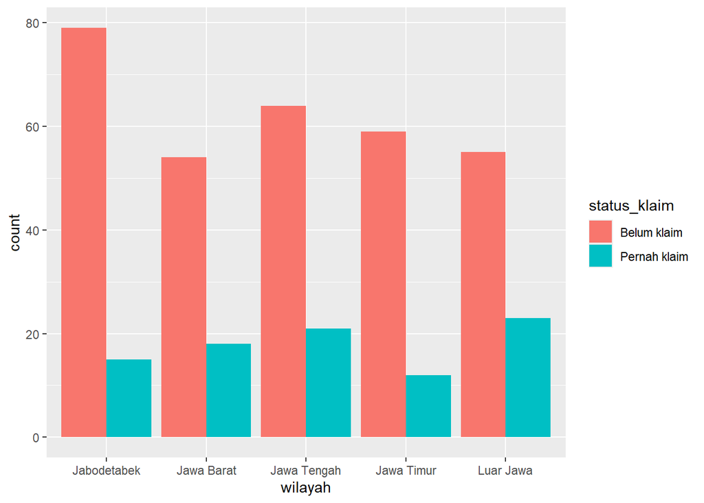

```r
ggplot(
  data_raw,
  aes(
    x = wilayah,
    fill = status_klaim
  )
) +
  geom_bar(position = "dodge")
```

Kategori ditampilkan berdampingan.

Ini sangat berguna ketika ingin membandingkan jumlah antar kelompok secara langsung.

### `position = "fill"`

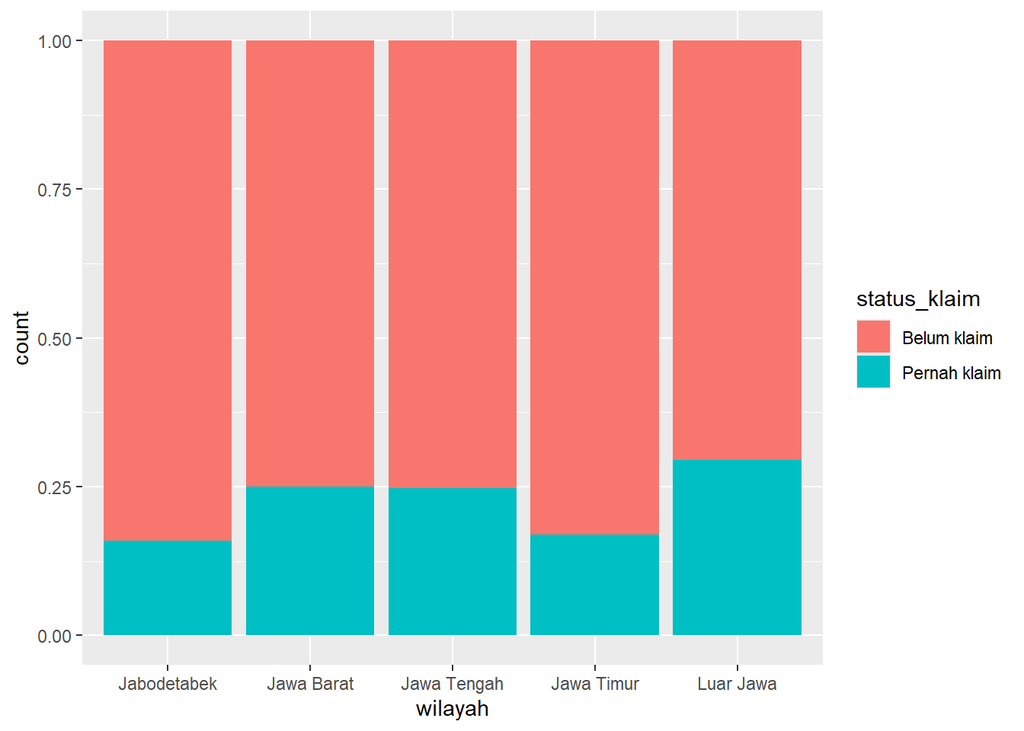

```r
ggplot(
  data_raw,
  aes(
    x = wilayah,
    fill = status_klaim
  )
) +
  geom_bar(position = "fill")
```

Setiap kelompok dibuat menjadi 100%.

Ini digunakan untuk membandingkan **proporsi**, bukan jumlah absolut.

## 19.7 `bins`

Khusus histogram.

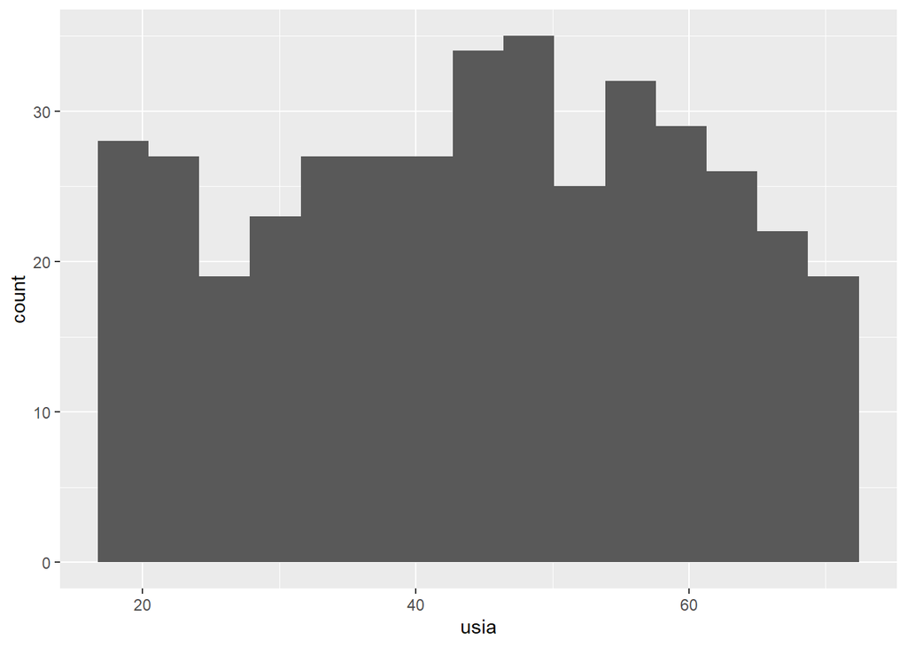

```r
ggplot(
  data_raw,
  aes(x = usia)
) +
  geom_histogram(bins = 15)
```

`bins` menentukan jumlah interval pada histogram.

Terlalu sedikit bins dapat menyembunyikan pola.

Terlalu banyak bins dapat membuat grafik terlalu berisik.

## 19.8 `binwidth`

Alternatif lain untuk mengatur lebar interval histogram.

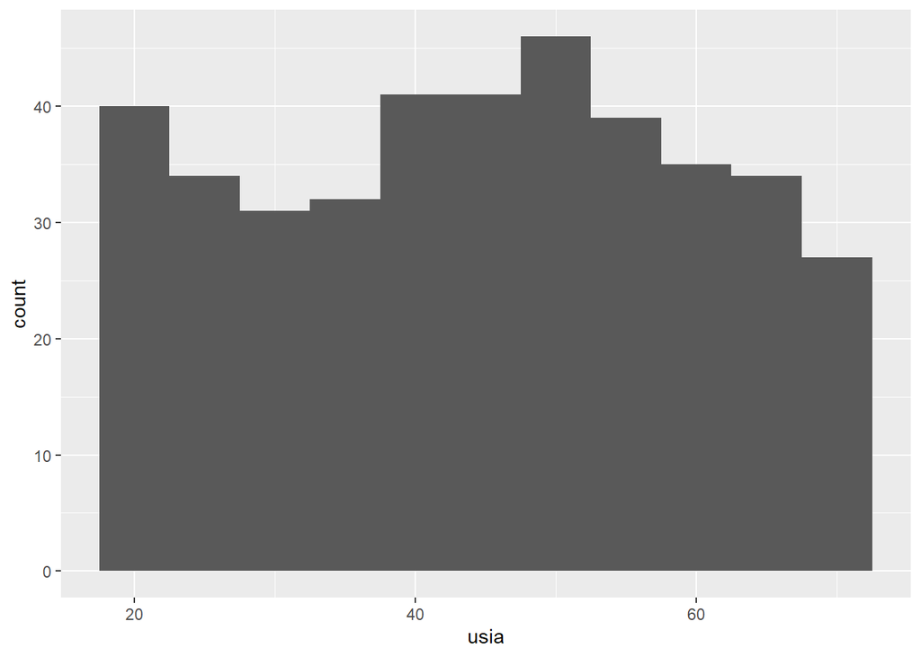

```r
ggplot(
  data_raw,
  aes(x = usia)
) +
  geom_histogram(binwidth = 5)
```

`binwidth = 5`

→ setiap interval memiliki lebar sekitar 5 tahun.

## 19.9 `coord_flip()`

Membalik orientasi koordinat.

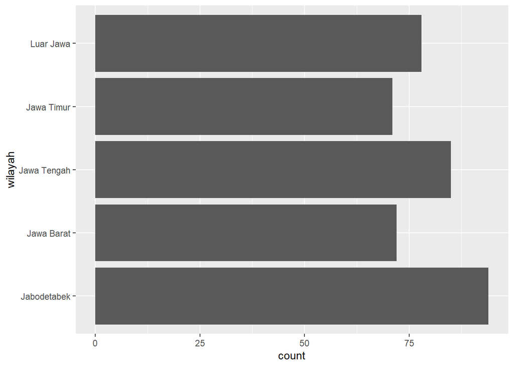

```r
ggplot(
  data_raw,
  aes(x = wilayah)
) +
  geom_bar() +
  coord_flip()
```

Sangat berguna jika nama kategori panjang.

## 19.10 `facet_wrap()`

Membuat panel terpisah berdasarkan satu variabel.

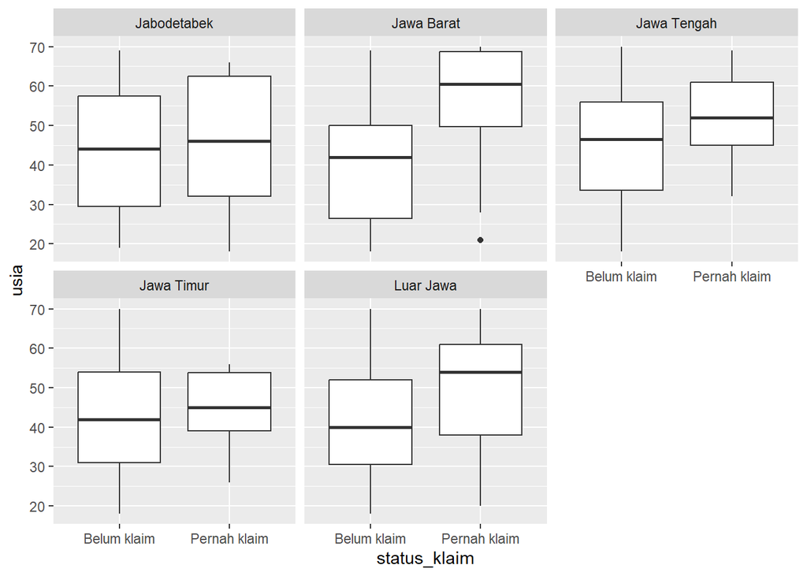

```r
ggplot(
  data_raw,
  aes(x = status_klaim, y = usia)
) +
  geom_boxplot() +
  facet_wrap(~ wilayah)
```

Bentuk umumnya:

```r
facet_wrap(~ variabel)
```

## 19.11 `facet_grid()`

Digunakan ketika ingin membuat panel berdasarkan dua arah kelompok.

Contoh:

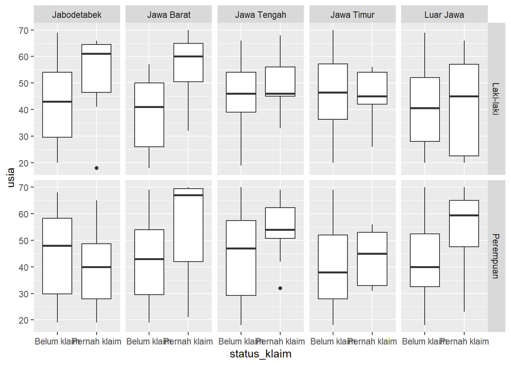

```r
ggplot(
  data_raw,
  aes(x = status_klaim, y = usia)
) +
  geom_boxplot() +
  facet_grid(jenis_kelamin ~ wilayah)
```

Format:

```r
facet_grid(baris ~ kolom)
```

Artinya:

- variabel sebelum `~` → baris;
- variabel setelah `~` → kolom.

Jangan menggunakan terlalu banyak facet jika membuat grafik sulit dibaca.

## 19.12 `labs()`

Digunakan untuk memberi konteks pada grafik.

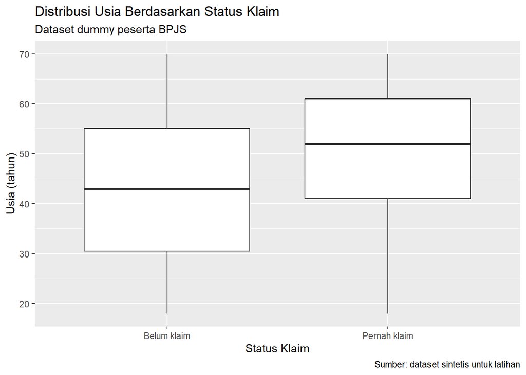

```r
ggplot(
  data_raw,
  aes(x = status_klaim, y = usia)
) +
  geom_boxplot() +
  labs(
    title = "Distribusi Usia Berdasarkan Status Klaim",
    subtitle = "Dataset dummy peserta BPJS",
    x = "Status Klaim",
    y = "Usia (tahun)",
    caption = "Sumber: dataset sintetis untuk latihan"
  )
```

Parameter penting:

- `title` → judul;
- `subtitle` → penjelasan tambahan;
- `x` → label X;
- `y` → label Y;
- `caption` → catatan/sumber.

## 19.13 `theme()`

`theme()` memungkinkan kita mengatur elemen tampilan.

Untuk pemula, cukup pahami bahwa:

```r
theme_minimal()
```

adalah pilihan praktis untuk membuat grafik lebih bersih.

Contoh:

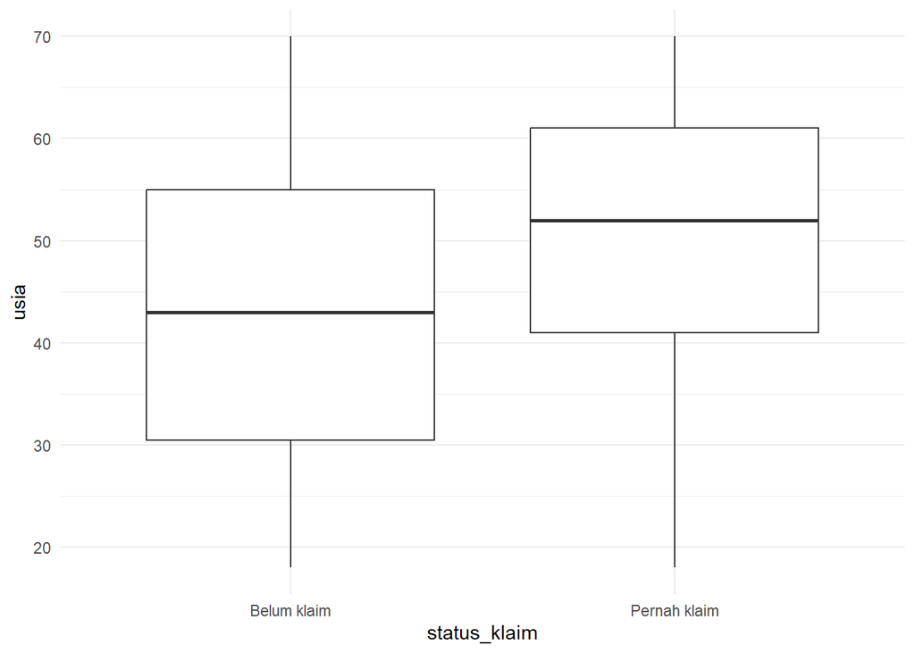

```r
ggplot(
  data_raw,
  aes(x = status_klaim, y = usia)
) +
  geom_boxplot() +
  theme_minimal()
```

Tidak perlu menghabiskan waktu ujian untuk membuat grafik sangat dekoratif.

**Prioritas:**

1. grafik tepat;
2. label jelas;
3. interpretasi tepat;
4. baru estetika.

## 19.14 Mengubah Urutan Kategori

Kadang urutan kategori default kurang nyaman dibaca.

Untuk latihan sederhana, kita dapat menggunakan `reorder()`.

Misalnya ingin mengurutkan wilayah berdasarkan rata-rata usia:

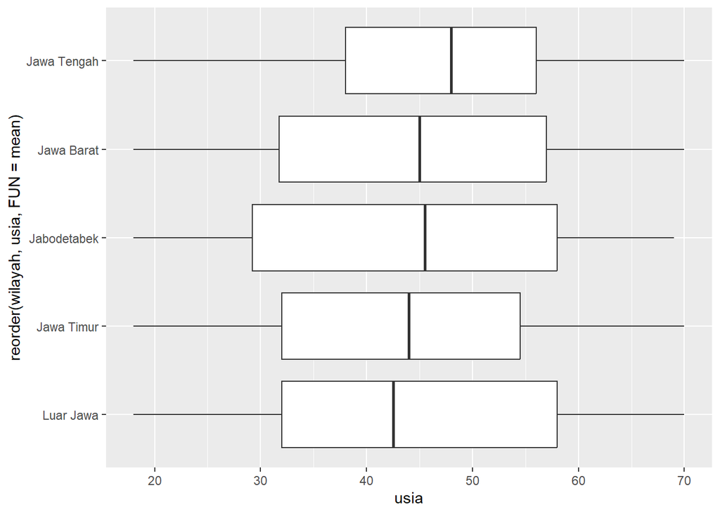

```r
ggplot(
  data_raw,
  aes(
    x = reorder(wilayah, usia, FUN = mean),
    y = usia
  )
) +
  geom_boxplot() +
  coord_flip()
```

### Apa fungsi `reorder()`?

Mengurutkan kategori berdasarkan nilai variabel lain.

Struktur sederhananya:

```r
reorder(kategori, nilai, FUN = fungsi)
```

Contoh:

```r
reorder(wilayah, usia, FUN = mean)
```

→ wilayah diurutkan berdasarkan rata-rata usia.

## 19.15 Parameter yang Dapat Dipasang Bersama

Contoh:

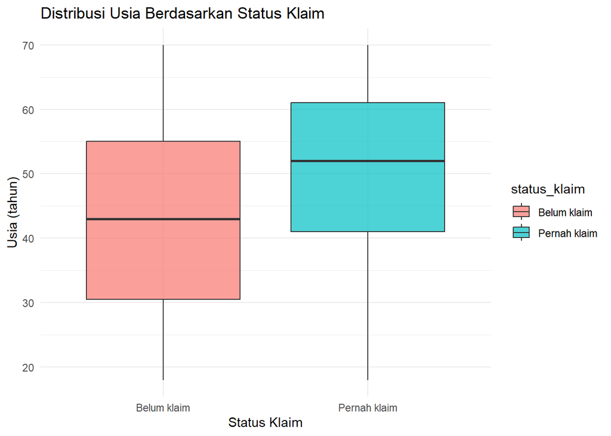

```r
ggplot(
  data_raw,
  aes(
    x = status_klaim,
    y = usia,
    fill = status_klaim
  )
) +
  geom_boxplot(alpha = 0.7) +
  labs(
    title = "Distribusi Usia Berdasarkan Status Klaim",
    x = "Status Klaim",
    y = "Usia (tahun)"
  ) +
  theme_minimal()
```

Perhatikan bahwa kita menggabungkan:

- `aes()` → mapping data;
- `fill` → kelompok;
- `alpha` → transparansi;
- `labs()` → informasi grafik;
- `theme_minimal()` → tampilan.

Jangan memasukkan semua parameter hanya karena bisa digunakan. Gunakan hanya jika membantu pembaca.

# 20. Menggunakan `dplyr` Sebelum Visualisasi

Kadang kita perlu meringkas data terlebih dahulu.

Contoh:

> Berapa rata-rata jumlah kunjungan berdasarkan status klaim?

```r
data_summary <- data_raw %>%
  group_by(status_klaim) %>%
  summarise(
    rata_kunjungan = mean(kunjungan_12_bulan),
    jumlah = n()
  )

data_summary
```

```
## # A tibble: 2 × 3
##   status_klaim rata_kunjungan jumlah
##   <chr>                 <dbl>  <int>
## 1 Belum klaim            3.74    311
## 2 Pernah klaim           5.55     89
```

### Penjelasan

`%>%`

→ meneruskan hasil dari satu langkah ke langkah berikutnya.

`group_by()`

→ membuat kelompok.

`summarise()`

→ membuat ringkasan.

`mean()`

→ menghitung rata-rata.

`n()`

→ menghitung jumlah observasi.

# 21. Membuat Grafik dari Data Ringkasan

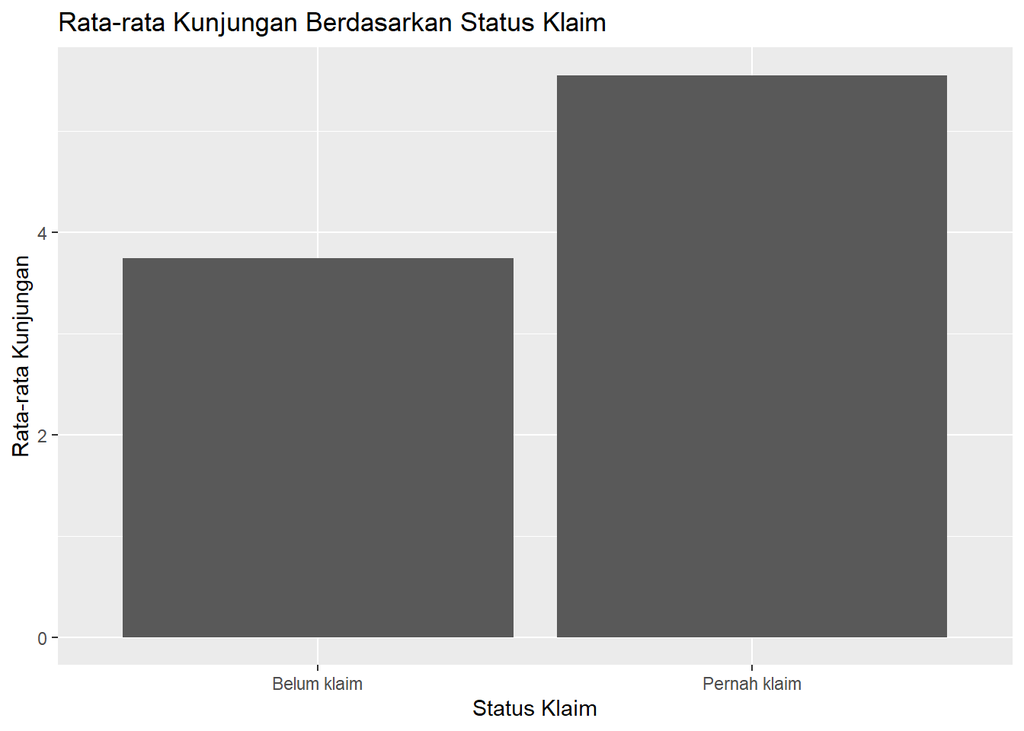

```r
ggplot(
  data_summary,
  aes(x = status_klaim, y = rata_kunjungan)
) +
  geom_col() +
  labs(
    title = "Rata-rata Kunjungan Berdasarkan Status Klaim",
    x = "Status Klaim",
    y = "Rata-rata Kunjungan"
  )
```

### `geom_col()` vs `geom_bar()`

`geom_bar()`

→ menghitung jumlah observasi dari data mentah.

`geom_col()`

→ menggunakan nilai yang sudah tersedia pada data.

Ini perbedaan penting.

# 22. Visualisasi untuk Menemukan Pola

Bagian ini menghubungkan seluruh materi sebelumnya: mengubah **pertanyaan klien** menjadi **pola yang perlu dicari**, lalu menjadi **grafik**.

## 22.1 Enam pola utama

| Pola | Maksudnya | Grafik |
| --- | --- | --- |
| **Difference** | Perbedaan nilai antar kelompok | Bar terurut, boxplot |
| **Association** | Dua variabel bergerak bersama | Scatter + `geom_smooth()` |
| **Distribution** | Bentuk dan rentang sebaran | Histogram, density, boxplot |
| **Trend** | Arah perubahan sepanjang waktu | Line chart, area chart |
| **Cluster** | Gumpalan sub-kelompok alami | Scatter + warna/facet |
| **Anomaly** | Nilai menyimpang dari pola umum | Boxplot, scatter |

## 22.2 Menerjemahkan pertanyaan klien menjadi grafik

| Pertanyaan klien | Pola | Variabel | Grafik |
| --- | --- | --- | --- |
| Wilayah mana dengan peserta terbanyak? | Difference | `wilayah` | Bar chart terurut |
| Apakah peserta PBI dan Non-PBI berbeda usianya? | Difference | `status_kepesertaan` × `usia` | Boxplot |
| Apakah kunjungan berkaitan dengan biaya klaim? | Association | `kunjungan_12_bulan` × `biaya_klaim` | Scatter + smooth |
| Berapa lama umumnya peserta menunggu? | Distribution | `waktu_tunggu_hari` | Histogram |
| Bagaimana kunjungan berubah tiap bulan? | Trend | `tahun_bulan` × kunjungan | Line chart |
| Adakah kelompok peserta dengan pola serupa? | Cluster | 2 numerik + warna | Scatter + `color` |
| Adakah biaya klaim yang tidak wajar? | Anomaly | `biaya_klaim` | Boxplot |
| Apakah komposisi layanan beda antar wilayah? | Composition | `wilayah` × `jenis_layanan` | 100% stacked bar |

### Contoh: mencari anomaly

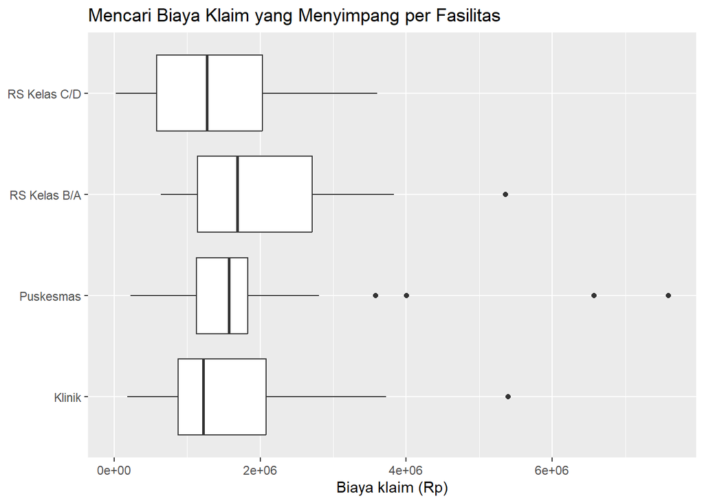

```r
data_raw %>%
  filter(status_klaim == "Pernah klaim") %>%
  ggplot(aes(x = fasilitas_utama, y = biaya_klaim)) +
  geom_boxplot() +
  coord_flip() +
  labs(
    title = "Mencari Biaya Klaim yang Menyimpang per Fasilitas",
    x = NULL, y = "Biaya klaim (Rp)"
  )
```

Titik yang muncul di luar kumis boxplot adalah kandidat outlier. Langkah berikutnya bukan langsung membuangnya, melainkan **memeriksanya**:

```r
data_raw %>%
  filter(status_klaim == "Pernah klaim") %>%
  arrange(desc(biaya_klaim)) %>%
  select(id_peserta, usia, wilayah, fasilitas_utama, jenis_layanan, biaya_klaim) %>%
  head(10)
```

```
##    id_peserta usia     wilayah fasilitas_utama jenis_layanan biaya_klaim
## 1    BPJS0299   69 Jawa Tengah       Puskesmas   Rawat Jalan     7591000
## 2    BPJS0305   22   Luar Jawa       Puskesmas   Rawat Jalan     6571000
## 3    BPJS0133   65 Jabodetabek          Klinik   Rawat Jalan     5395000
## 4    BPJS0125   58   Luar Jawa    RS Kelas B/A   Pemeriksaan     5358000
## 5    BPJS0078   35 Jabodetabek       Puskesmas   Rawat Jalan     4001000
## 6    BPJS0165   69  Jawa Barat    RS Kelas B/A          Obat     3830000
## 7    BPJS0059   37 Jawa Tengah          Klinik          Obat     3723000
## 8    BPJS0019   39   Luar Jawa    RS Kelas C/D   Rawat Jalan     3601000
## 9    BPJS0203   58 Jawa Tengah       Puskesmas          Obat     3581000
## 10   BPJS0183   19 Jabodetabek          Klinik          Obat     3158000
```

> Biasakan menuliskan pertanyaan dalam satu kalimat sebelum membuka R. Kalimat itulah yang nanti menjadi judul grafiknya.

# 23. Interpretasi Visualisasi: What → Pattern → Implication

Bagian sebelumnya sudah memperkenalkan pola kalimat interpretasi. Bagian ini memberikan kerangka tiga langkah yang dapat dipakai untuk setiap grafik.

## 23.1 Kerangka tiga langkah

[output not shown]

## 23.2 Contoh penerapan lengkap

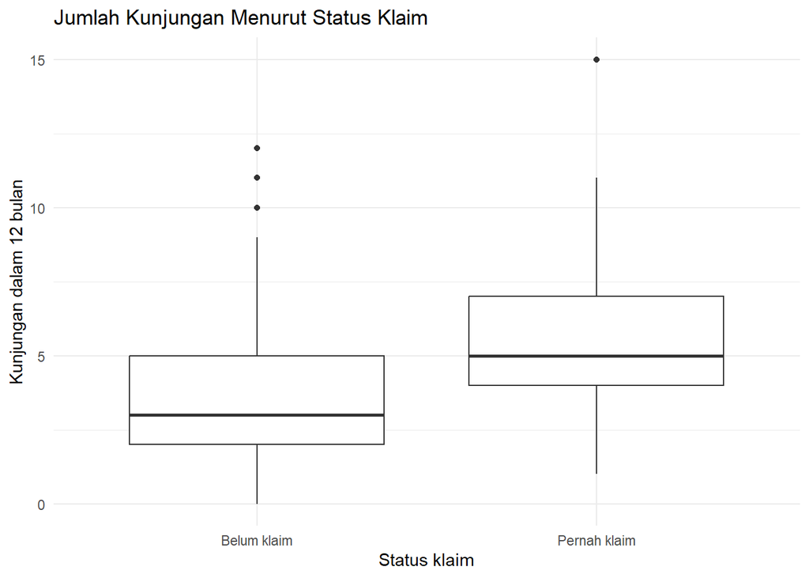

```r
ggplot(data_raw, aes(x = status_klaim, y = kunjungan_12_bulan)) +
  geom_boxplot() +
  labs(
    title = "Jumlah Kunjungan Menurut Status Klaim",
    x = "Status klaim",
    y = "Kunjungan dalam 12 bulan"
  ) +
  theme_minimal()
```

## 23.3 Observasi vs kesimpulan kausal

| Hindari (overclaim) | Gunakan (observasi) |
| --- | --- |
| “Jumlah kunjungan menyebabkan klaim.” | “Peserta yang pernah klaim terlihat memiliki jumlah kunjungan lebih tinggi.” |
| “Penyakit kronis terbukti meningkatkan biaya.” | “Biaya klaim cenderung lebih tinggi pada peserta berpenyakit kronis.” |
| “Wilayah X adalah penyebab waktu tunggu lama.” | “Median waktu tunggu di wilayah X terlihat paling lama.” |
| “Tahun depan klaim akan naik.” | “Tren enam bulan terakhir menunjukkan kenaikan.” |

Kata **“menyebabkan”**, **“terbukti”**, dan **“akan”** menuntut bukti yang tidak dapat diberikan oleh grafik deskriptif.

Gunakan kata **“cenderung”**, **“terkait”**, **“terlihat lebih tinggi pada”**, dan sebutkan batasan datanya.

## 23.4 Bila polanya tidak jelas

Menuliskan “tidak terlihat perbedaan” adalah jawaban yang sah, dan sering lebih benar daripada memaksakan temuan.

> Secara visual, distribusi kedua kelompok terlihat relatif serupa sehingga belum terlihat perbedaan yang jelas pada variabel tersebut.

# 24. Latihan Pola Soal PAI

## 24.1 Kasus 1 — Karakteristik Klaim

> Perusahaan ingin mengetahui apakah terdapat karakteristik tertentu yang berpotensi membedakan peserta yang pernah mengajukan klaim dengan peserta yang belum mengajukan klaim.

Gunakan data:

- `usia`
- `jenis_kelamin`
- `wilayah`
- `status_kepesertaan`
- `penyakit_kronis`
- `kunjungan_12_bulan`
- `waktu_tunggu_hari`

### Tugas

Untuk setiap variabel:

1. tentukan tipe variabel;
2. tentukan grafik yang sesuai;
3. buat grafik;
4. tuliskan interpretasi singkat.

### Panduan berpikir

| Variabel | Tipe | Grafik yang dapat digunakan |
| --- | --- | --- |
| Usia | Numerik | Boxplot |
| Jenis kelamin | Kategorikal | Bar/100% stacked bar |
| Wilayah | Kategorikal | Bar/100% stacked bar |
| Status kepesertaan | Kategorikal | Bar/100% stacked bar |
| Penyakit kronis | Kategorikal | Bar/100% stacked bar |
| Kunjungan | Numerik | Boxplot |
| Waktu tunggu | Numerik | Boxplot |

# 25. Latihan Pola Soal Agustus 2025

## 25.1 A. Kondisi peserta berdasarkan wilayah

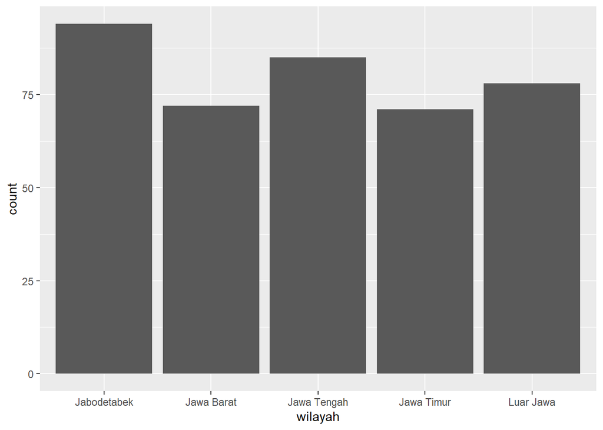

```r
ggplot(data_raw, aes(x = wilayah)) +
  geom_bar()
```

**Tugas:** Jelaskan wilayah dengan jumlah peserta terbanyak.

## 25.2 B. Status kepesertaan berdasarkan wilayah

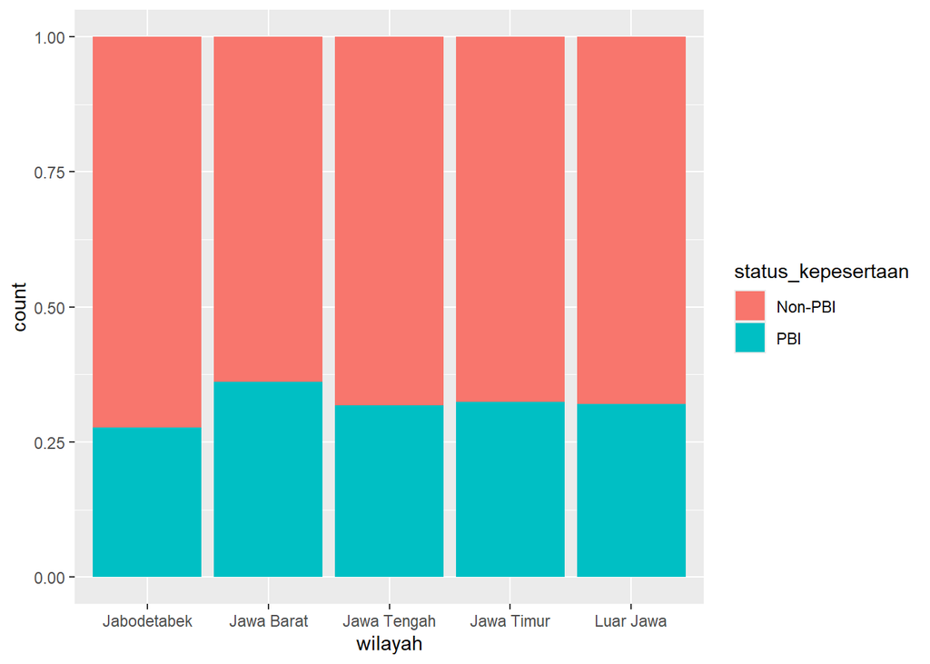

```r
ggplot(
  data_raw,
  aes(x = wilayah, fill = status_kepesertaan)
) +
  geom_bar(position = "fill")
```

**Tugas:** Apakah komposisi PBI dan Non-PBI terlihat sama di setiap wilayah?

## 25.3 C. Hubungan usia dan kunjungan

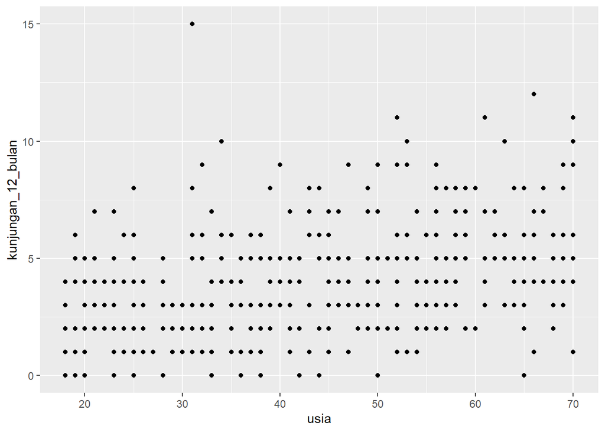

```r
ggplot(
  data_raw,
  aes(x = usia, y = kunjungan_12_bulan)
) +
  geom_point()
```

**Tugas:** Apakah terlihat hubungan antara usia dan jumlah kunjungan?

## 25.4 D. Perbandingan biaya klaim

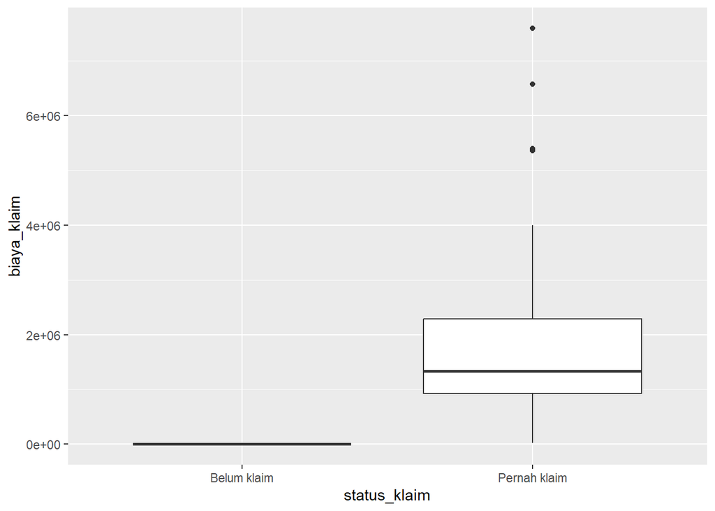

```r
ggplot(
  data_raw,
  aes(x = status_klaim, y = biaya_klaim)
) +
  geom_boxplot()
```

**Tugas:** Bandingkan distribusi biaya klaim antara kedua kelompok.

# 26. Latihan Pola Soal Oktober 2024

Misalkan klien ingin mengetahui apakah faktor berikut berpotensi berkaitan dengan status klaim:

- wilayah;
- jenis kelamin;
- usia;
- penyakit kronis;
- fasilitas utama.

### Tugas

Buat visualisasi yang sesuai untuk masing-masing faktor.

Contoh untuk usia:

```r
ggplot(
  data_raw,
  aes(x = status_klaim, y = usia)
) +
  geom_boxplot()
```

Contoh untuk penyakit kronis:

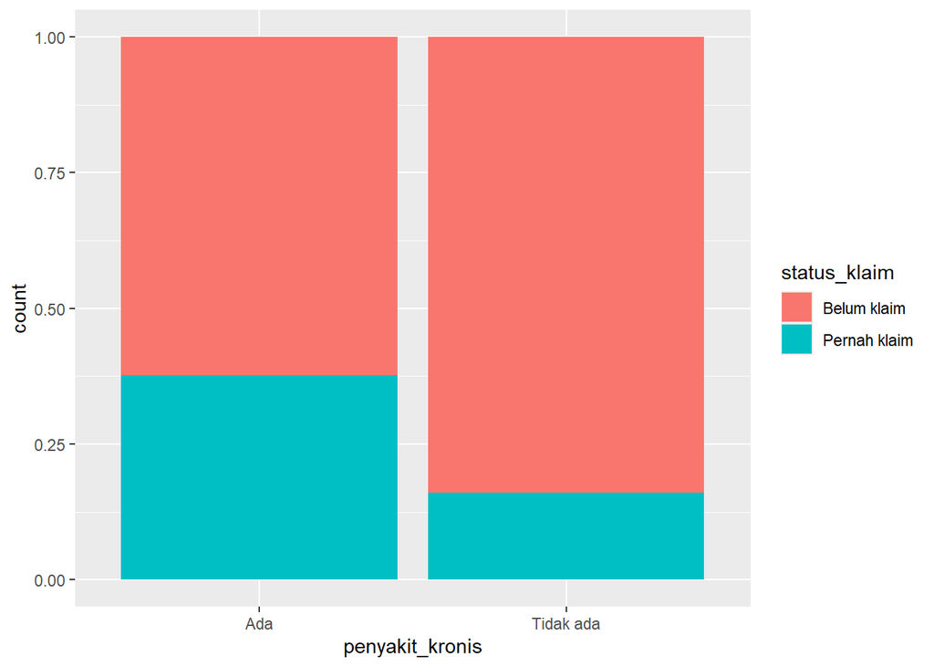

```r
ggplot(
  data_raw,
  aes(x = penyakit_kronis, fill = status_klaim)
) +
  geom_bar(position = "fill")
```

# 27. Strategi Menjawab Soal Visualization

Ketika menerima soal PAI, jangan langsung mengetik kode.

Gunakan urutan:

## 27.1 STEP 1 — Apa pertanyaannya?

Contoh:

> Apakah ada karakteristik yang membedakan peserta yang pernah klaim dan belum klaim?

Berarti kita harus **membandingkan dua kelompok**.

## 27.2 STEP 2 — Apa variabel yang dibandingkan?

Contoh:

`status_klaim` dengan `usia`.

## 27.3 STEP 3 — Apa tipe variabelnya?

`status_klaim` → kategorikal.

`usia` → numerik.

## 27.4 STEP 4 — Grafik apa yang sesuai?

Categorical × numerical

→ **boxplot**.

## 27.5 STEP 5 — Buat grafik

```r
ggplot(data_raw, aes(x = status_klaim, y = usia)) +
  geom_boxplot()
```

## 27.6 STEP 6 — Interpretasikan

Jawab:

> **Apa yang terlihat?**

bukan:

> **Apa yang saya ingin buktikan?**

# 28. Cheat Sheet Pemilihan Grafik

| Pertanyaan | Tipe Variabel | Grafik |
| --- | --- | --- |
| Berapa banyak tiap kategori? | Cat | Bar chart |
| Bagaimana distribusi variabel numerik? | Num | Histogram |
| Apakah ada outlier/distribusi berbeda? | Num | Boxplot |
| Apakah numerik berbeda antar kelompok? | Cat + Num | Boxplot |
| Apakah dua kategori memiliki komposisi berbeda? | Cat + Cat | Bar / 100% stacked bar |
| Apakah dua numerik berkaitan? | Num + Num | Scatter plot |
| Bagaimana pola antar banyak kelompok? | Group | Color / fill / facet |
| Bagaimana tren menurut waktu? | Waktu + Num | Line chart |

# 29. Pola Interpretasi yang Aman

Gunakan struktur:

> **Berdasarkan grafik, terlihat bahwa [kelompok A] memiliki [pola/karakteristik] dibandingkan [kelompok B].**

Contoh:

> Berdasarkan boxplot, peserta yang pernah klaim terlihat memiliki median jumlah kunjungan yang lebih tinggi dibandingkan peserta yang belum klaim.

Jika pola tidak jelas:

> Secara visual, distribusi kedua kelompok terlihat relatif serupa sehingga belum terlihat perbedaan yang jelas pada variabel tersebut.

Hindari:

> “Jumlah kunjungan menyebabkan klaim.”

Gunakan:

> “Peserta yang pernah klaim terlihat memiliki jumlah kunjungan yang lebih tinggi.”

Visualisasi menunjukkan **pola/asosiasi**, bukan otomatis **sebab-akibat**.

# 30. Final Challenge — Simulasi PAI

## 30.1 Kasus

Sebuah organisasi ingin memahami karakteristik peserta BPJS yang pernah menggunakan layanan klaim dibandingkan peserta yang belum pernah klaim.

Dengan menggunakan grafik yang sesuai, telusuri apakah terdapat karakteristik tertentu yang berpotensi membedakan kedua kelompok tersebut.

Gunakan minimal:

- `usia`;
- `jenis_kelamin`;
- `wilayah`;
- `status_kepesertaan`;
- `penyakit_kronis`;
- `kunjungan_12_bulan`;
- `waktu_tunggu_hari`.

### Instruksi

Untuk setiap variabel:

1. identifikasi tipe variabel;
2. tentukan grafik yang sesuai;
3. buat visualisasi;
4. berikan interpretasi singkat;
5. tentukan variabel mana yang secara visual menunjukkan perbedaan paling terlihat.

### Checklist sebelum menjawab

- Saya memahami pertanyaannya.
- Saya tahu kelompok yang ingin dibandingkan.
- Saya sudah menentukan tipe variabel.
- Saya memilih grafik berdasarkan tujuan analisis.
- Judul dan label grafik jelas.
- Grafik dapat dibaca.
- Interpretasi menyebutkan pola yang terlihat.
- Saya tidak menyimpulkan sebab-akibat hanya dari grafik.
- Saya tidak membuat satu grafik yang terlalu kompleks jika beberapa grafik sederhana lebih jelas.

# 31. Checklist Kualitas Grafik

Gunakan checklist ini sebelum menyerahkan grafik, baik dalam pekerjaan maupun ujian.

## 31.1 Isi dan ketepatan

- Grafik menjawab pertanyaan yang benar-benar diajukan.
- Jenis grafik sesuai dengan kombinasi tipe variabel.
- Sumbu Y pada bar chart dimulai dari nol.
- Agregasi sudah tepat: jumlah, rata-rata, atau median.
- Baris yang tidak relevan sudah disaring (misalnya `biaya_klaim = 0` untuk peserta belum klaim).
- Outlier sudah diperiksa, bukan diam-diam dibuang.

## 31.2 Keterbacaan

- Judul memuat temuan, bukan sekadar nama variabel.
- Sumbu memiliki label beserta satuannya.
- Kategori diurutkan secara bermakna, bukan menurut abjad.
- Label kategori panjang ditangani dengan `coord_flip()`.
- Angka besar diformat agar mudah dibaca.

## 31.3 Komunikasi

- Hanya ada satu pesan utama per grafik.
- Warna membawa informasi, maksimal 5–7 kategori.
- Legend diberi judul yang dipahami pembaca.
- Interpretasi tertulis tidak melampaui bukti visualnya.
- Tidak ada klaim sebab-akibat yang tidak didukung desain analisis.

# 32. Glosarium

## 32.1 Fungsi `ggplot2`

| Istilah | Arti |
| --- | --- |
| `ggplot()` | Membuat kanvas dan menetapkan sumber data |
| `aes()` | Aesthetic mapping: memetakan kolom data ke properti visual |
| `geom_point()` | Layer titik, untuk scatter plot |
| `geom_line()` | Layer garis, untuk tren waktu |
| `geom_bar()` | Layer batang, menghitung frekuensi otomatis |
| `geom_col()` | Layer batang memakai nilai `y` apa adanya |
| `geom_histogram()` | Histogram untuk variabel numerik |
| `geom_density()` | Kurva kepadatan sebaran numerik |
| `geom_boxplot()` | Boxplot: median, kuartil, outlier |
| `geom_violin()` | Bentuk kepadatan sebaran per kelompok |
| `geom_area()` | Area di bawah garis sepanjang waktu |
| `geom_smooth()` | Garis tren beserta area kepercayaan |
| `geom_jitter()` | Titik yang digeser acak untuk mengurangi tumpang tindih |
| `geom_text()` | Menuliskan label nilai di dalam grafik |
| `geom_hline()` / `geom_vline()` | Garis bantu horizontal / vertikal |
| `annotate()` | Menambahkan teks atau bentuk secara manual |
| `facet_wrap()` | Panel berdasarkan satu variabel |
| `facet_grid()` | Panel matriks berdasarkan dua variabel |
| `scale_*_continuous()` | Mengatur skala dan format sumbu numerik |
| `scale_fill_manual()` | Menentukan warna isi secara manual |
| `coord_flip()` | Membalik sumbu X dan Y |
| `coord_polar()` | Mengubah koordinat menjadi polar (pie chart) |
| `labs()` | Judul, subtitle, caption, dan label sumbu |
| `theme_minimal()` | Tema tampilan bersih |
| `ggsave()` | Menyimpan grafik ke file gambar |

## 32.2 Konsep visualisasi

| Istilah | Arti |
| --- | --- |
| Grammar of Graphics | Kerangka berpikir: grafik = data + aes + geom + lapisan opsional |
| Aesthetic mapping | Memetakan kolom data ke properti visual (di dalam `aes()`) |
| Setting | Menetapkan properti visual secara manual (di luar `aes()`) |
| Layer | Satu lapisan grafik, biasanya satu `geom` |
| Stat transformation | Perhitungan statistik sebelum data digambar |
| Small multiples | Panel-panel kecil untuk tiap kelompok (hasil facet) |
| Tidy data | 1 baris = 1 observasi, 1 kolom = 1 variabel |
| Binwidth | Lebar selang pengelompokan nilai pada histogram |
| Skewness | Kemiringan distribusi ke kiri atau ke kanan |
| Outlier | Nilai yang jauh menyimpang dari kelompok utama |
| Overplotting | Titik saling menutupi karena data terlalu padat |
| Univariate | Analisis yang melibatkan satu variabel |
| Bivariate | Analisis yang melibatkan dua variabel |
| Exploratory | Visualisasi untuk menemukan sesuatu yang belum diketahui |
| Explanatory | Visualisasi untuk menyampaikan temuan kepada orang lain |

## 32.3 Fungsi `dplyr`

| Istilah | Arti |
| --- | --- |
| `filter()` | Menyaring baris berdasarkan kondisi |
| `select()` | Memilih kolom tertentu |
| `mutate()` | Membuat atau mengubah kolom |
| `case_when()` | Membuat kategori baru berdasarkan beberapa kondisi |
| `group_by()` | Menandai kolom pengelompokan |
| `summarise()` | Meringkas tiap kelompok menjadi satu baris |
| `count()` | Menghitung jumlah baris per kategori |
| `arrange()` | Mengurutkan baris |
| `n()` | Menghitung jumlah observasi dalam kelompok |
| `reorder()` | Mengurutkan kategori berdasarkan nilai numerik |
| `%>%` | Pipe: mengalirkan hasil ke fungsi berikutnya |

# 33. Ringkasan Materi

Inti Data Visualization untuk PAI dapat diringkas menjadi:

**Question**

↓

**Identify Variables**

↓

**Identify Variable Types**

↓

**Choose Appropriate Plot**

↓

**Create Plot in `ggplot2`**

↓

**Compare / Find Pattern**

↓

**Interpret**

↓

**Answer the Client’s Question**

```r
ggplot(data, aes(...)) +
  geom_...()
```

> **Jangan mulai dari “mau pakai grafik apa?”. Mulailah dari “pertanyaan apa yang ingin dijawab?”.**